# **Problem Statement**

## Business Context

Renewable energy sources play an increasingly important role in the global energy mix, as the effort to reduce the environmental impact of energy production increases.

Out of all the renewable energy alternatives, wind energy is one of the most developed technologies worldwide. The U.S Department of Energy has put together a guide to achieving operational efficiency using predictive maintenance practices.

Predictive maintenance uses sensor information and analysis methods to measure and predict degradation and future component capability. The idea behind predictive maintenance is that failure patterns are predictable and if component failure can be predicted accurately and the component is replaced before it fails, the costs of operation and maintenance will be much lower.

The sensors fitted across different machines involved in the process of energy generation collect data related to various environmental factors (temperature, humidity, wind speed, etc.) and additional features related to various parts of the wind turbine (gearbox, tower, blades, break, etc.).

## Objective

“ReneWind” is a company working on improving the machinery/processes involved in the production of wind energy using machine learning and has collected data of generator failure of wind turbines using sensors. They have shared a ciphered version of the data, as the data collected through sensors is confidential (the type of data collected varies with companies). Data has 40 predictors, 20000 observations in the training set and 5000 in the test set.

The objective is to build various classification models, tune them, and find the best one that will help identify failures so that the generators could be repaired before failing/breaking to reduce the overall maintenance cost. The nature of predictions made by the classification model will translate as follows:

- True positives (TP) are failures correctly predicted by the model. These will result in repairing costs.
- False negatives (FN) are real failures where there is no detection by the model. These will result in replacement costs.
- False positives (FP) are detections where there is no failure. These will result in inspection costs.

It is given that the cost of repairing a generator is much less than the cost of replacing it, and the cost of inspection is less than the cost of repair.

“1” in the target variables should be considered as “failure” and “0” represents “No failure”.

## Data Description

The data provided is a transformed version of the original data which was collected using sensors.

- Train.csv - To be used for training and tuning of models.
- Test.csv - To be used only for testing the performance of the final best model.

Both the datasets consist of 40 predictor variables and 1 target variable.

# **Installing and Importing the necessary libraries**

```python
# Installing the libraries with the specified version
!pip install --no-deps tensorflow==2.19.0 scikit-learn==1.6.1 matplotlib===3.10.0 seaborn==0.13.2 numpy==2.0.2 pandas==2.2.2 -q --user --no-warn-script-location
```

**Note**:

- After running the above cell, kindly restart the runtime (for Google Colab) or notebook kernel (for Jupyter Notebook), and run all cells sequentially from the next cell.
- On executing the above line of code, you might see a warning regarding package dependencies. This error message can be ignored as the above code ensures that all necessary libraries and their dependencies are maintained to successfully execute the code in **this notebook**.

```python
# Importing necessary libraries
import pandas as pd
import numpy as np
import matplotlib.pyplot as plt
import seaborn as sns
import time
import warnings
warnings.filterwarnings('ignore')

# TensorFlow and Keras imports
import tensorflow as tf
from tensorflow import keras
from keras.models import Sequential
from keras.layers import Dense, Dropout
from keras import backend

# Scikit-learn imports
from sklearn.model_selection import train_test_split
from sklearn.preprocessing import StandardScaler
from sklearn.metrics import confusion_matrix, classification_report, f1_score
from sklearn.utils.class_weight import compute_class_weight

# Set style for plots
sns.set_style('whitegrid')
plt.rcParams['figure.figsize'] = (10, 6)
%matplotlib inline
```

# **Loading the Data**

```python
# uncomment and run the following lines for Google Colab
# from google.colab import drive
# drive.mount('/content/drive')
```

# **Data Overview**

```python
# Load the data
train_dataset = pd.read_csv('Train.csv')
test_dataset = pd.read_csv('Test.csv')

# Create a copy for analysis
orig_dataset = train_dataset.copy()

# Basic information about the dataset
print("=" * 80)
print("DATA OVERVIEW")
print("=" * 80)
print(f"\nShape of Training Dataset: {train_dataset.shape}")
print(f"Shape of Test Dataset: {test_dataset.shape}")
print(f"\nNumber of Features (Predictors): {train_dataset.shape[1] - 1}")
print(f"Number of Observations (Training): {train_dataset.shape[0]}")
print(f"Number of Observations (Test): {test_dataset.shape[0]}")

# Display first few rows
print("\n" + "=" * 80)
print("First 5 rows of the training dataset:")
print("=" * 80)
print(train_dataset.head())

# Display basic statistics
print("\n" + "=" * 80)
print("Statistical Summary of Numerical Features:")
print("=" * 80)
print(train_dataset.describe())

# Check data types
print("\n" + "=" * 80)
print("Data Types and Non-null Counts:")
print("=" * 80)
print(train_dataset.info())

# Check for missing values
print("\n" + "=" * 80)
print("Missing Values Analysis:")
print("=" * 80)
missing_values = train_dataset.isnull().sum()
missing_df = pd.DataFrame({
    'Missing Count': missing_values
})
missing_df = missing_df[missing_df['Missing Count'] > 0].sort_values('Missing Count', ascending=False)
if len(missing_df) > 0:
    print(missing_df)
else:
    print("No missing values found in the dataset!")

# Target variable distribution
print("\n" + "=" * 80)
print("Target Variable Distribution:")
print("=" * 80)
target_counts = train_dataset['Target'].value_counts()
target_percent = train_dataset['Target'].value_counts(normalize=True) * 100
target_dist = pd.DataFrame({
    'Count': target_counts,
    'Percentage': target_percent
})
print(target_dist)
print(f"\nClass Imbalance Ratio: {target_counts[0] / target_counts[1]:.2f}:1")
```

```
================================================================================
DATA OVERVIEW
================================================================================

Shape of Training Dataset: (20000, 41)
Shape of Test Dataset: (5000, 41)

Number of Features (Predictors): 40
Number of Observations (Training): 20000
Number of Observations (Test): 5000

================================================================================
First 5 rows of the training dataset:
================================================================================
         V1        V2        V3        V4        V5        V6        V7  \
0 -4.464606 -4.679129  3.101546  0.506130 -0.221083 -2.032511 -2.910870
1  3.365912  3.653381  0.909671 -1.367528  0.332016  2.358938  0.732600
2 -3.831843 -5.824444  0.634031 -2.418815 -1.773827  1.016824 -2.098941
3  1.618098  1.888342  7.046143 -1.147285  0.083080 -1.529780  0.207309
4 -0.111440  3.872488 -3.758361 -2.982897  3.792714  0.544960  0.205433

         V8        V9       V10  ...       V32       V33        V34       V35  \
0  0.050714 -1.522351  3.761892  ...  3.059700 -1.690440   2.846296  2.235198
1 -4.332135  0.565695 -0.101080  ... -1.795474  3.032780  -2.467514  1.894599
2 -3.173204 -2.081860  5.392621  ... -0.257101  0.803550   4.086219  2.292138
3 -2.493629  0.344926  2.118578  ... -3.584425 -2.577474   1.363769  0.622714
4  4.848994 -1.854920 -6.220023  ...  8.265896  6.629213 -10.068689  1.222987

        V36       V37       V38       V39       V40  Target
0  6.667486  0.443809 -2.369169  2.950578 -3.480324       0
1 -2.297780 -1.731048  5.908837 -0.386345  0.616242       0
2  5.360850  0.351993  2.940021  3.839160 -4.309402       0
3  5.550100 -1.526796  0.138853  3.101430 -1.277378       0
4 -3.229763  1.686909 -2.163896 -3.644622  6.510338       0

[5 rows x 41 columns]

================================================================================
Statistical Summary of Numerical Features:
================================================================================
```

[output cut: 106 more lines]

```
Missing Values Analysis:
================================================================================
    Missing Count
V1             18
V2             18

================================================================================
Target Variable Distribution:
================================================================================
        Count  Percentage
Target
0       18890       94.45
1        1110        5.55

Class Imbalance Ratio: 17.02:1
```

# **Exploratory Data Analysis**

## Univariate analysis

```
================================================================================
TARGET VARIABLE DISTRIBUTION
================================================================================
```

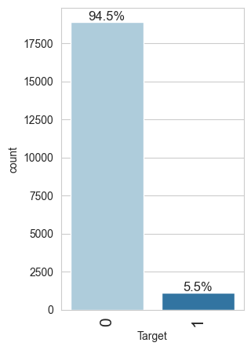

```
Target Variable Statistics:
Target
0    18890
1     1110
Name: count, dtype: int64

Class 0 (No Failure): 18890 (94.45%)
Class 1 (Failure): 1110 (5.55%)

================================================================================
UNIVARIATE ANALYSIS OF NUMERICAL FEATURES
================================================================================
```

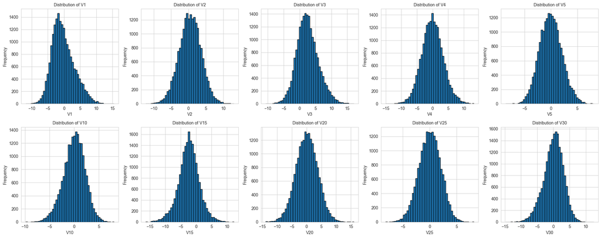

```
Box Plots for Outlier Detection (Sample Features):
```

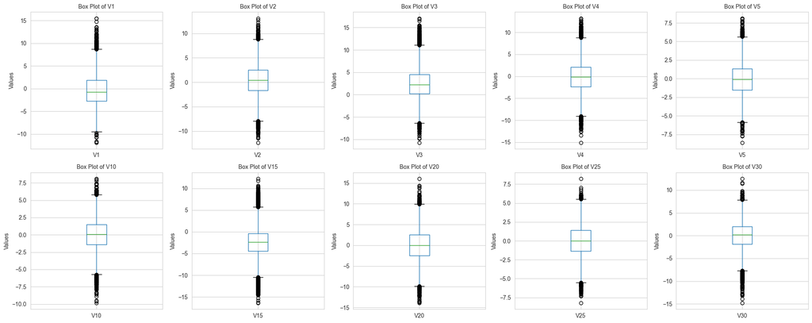

```
Summary Statistics for All Features:
                 V1            V2            V3            V4            V5  \
count  19982.000000  19982.000000  20000.000000  20000.000000  20000.000000
mean      -0.271996      0.440430      2.484699     -0.083152     -0.053752
std        3.441625      3.150784      3.388963      3.431595      2.104801
min      -11.876451    -12.319951    -10.708139    -15.082052     -8.603361
25%       -2.737146     -1.640674      0.206860     -2.347660     -1.535607
50%       -0.747917      0.471536      2.255786     -0.135241     -0.101952
75%        1.840112      2.543967      4.566165      2.130615      1.340480
max       15.493002     13.089269     17.090919     13.236381      8.133797

                 V6            V7            V8            V9           V10  \
count  20000.000000  20000.000000  20000.000000  20000.000000  20000.000000
mean      -0.995443     -0.879325     -0.548195     -0.016808     -0.012998
std        2.040970      1.761626      3.295756      2.160568      2.193201
min      -10.227147     -7.949681    -15.657561     -8.596313     -9.853957
25%       -2.347238     -2.030926     -2.642665     -1.494973     -1.411212
50%       -1.000515     -0.917179     -0.389085     -0.067597      0.100973
75%        0.380330      0.223695      1.722965      1.409203      1.477045
max        6.975847      8.006091     11.679495      8.137580      8.108472

       ...           V32           V33           V34           V35  \
count  ...  20000.000000  20000.000000  20000.000000  20000.000000
mean   ...      0.303799      0.049825     -0.462702      2.229620
std    ...      5.500400      3.575285      3.183841      2.937102
min    ...    -19.876502    -16.898353    -17.985094    -15.349803
25%    ...     -3.420469     -2.242857     -2.136984      0.336191
50%    ...      0.052073     -0.066249     -0.255008      2.098633
75%    ...      3.761722      2.255134      1.436935      4.064358
max    ...     23.633187     16.692486     14.358213     15.291065

                V36           V37           V38           V39           V40  \
count  20000.000000  20000.000000  20000.000000  20000.000000  20000.000000
mean       1.514809      0.011316     -0.344025      0.890653     -0.875630
std        3.800860      1.788165      3.948147      1.753054      3.012155
min      -14.833178     -5.478350    -17.375002     -6.438880    -11.023935
25%       -0.943809     -1.255819     -2.987638     -0.272250     -2.940193
50%        1.566526     -0.128435     -0.316849      0.919261     -0.920806
75%        3.983939      1.175533      2.279399      2.057540      1.119897
max       19.329576      7.467006     15.289923      7.759877     10.654265

             Target
count  20000.000000
mean       0.055500
std        0.228959
min        0.000000
25%        0.000000
50%        0.000000
75%        0.000000
max        1.000000

[8 rows x 41 columns]
```

```python
# UNIVARIATE ANALYSIS

# Function to create labeled barplots
def labeled_barplot(data, feature, perc=False, n=None):
    """
    Barplot with percentage at the top
    data: dataframe
    feature: dataframe column
    perc: whether to display percentages instead of count (default is False)
    n: displays the top n category levels (default is None, i.e., display all levels)
    """
    total = len(data[feature])
    count = data[feature].nunique()
    if n is None:
        plt.figure(figsize=(count + 1, 5))
    else:
        plt.figure(figsize=(n + 1, 5))

    plt.xticks(rotation=90, fontsize=15)
    ax = sns.countplot(
        data=data,
        x=feature,
        palette="Paired",
        order=data[feature].value_counts().index[:n].sort_values(),
    )

    for p in ax.patches:
        if perc == True:
            label = "{:.1f}%".format(100 * p.get_height() / total)
        else:
            label = p.get_height()

        x = p.get_x() + p.get_width() / 2
        y = p.get_height()

        ax.annotate(
            label,
            (x, y),
            ha="center",
            va="center",
            size=12,
            xytext=(0, 5),
            textcoords="offset points",
        )
    plt.show()

# Target variable distribution
print("=" * 80)
print("TARGET VARIABLE DISTRIBUTION")
print("=" * 80)
labeled_barplot(train_dataset, 'Target', perc=True)

# Distribution statistics for target
print("\nTarget Variable Statistics:")
print(train_dataset['Target'].value_counts())
print(f"\nClass 0 (No Failure): {(train_dataset['Target'] == 0).sum()} ({(train_dataset['Target'] == 0).sum() / len(train_dataset) * 100:.2f}%)")
print(f"Class 1 (Failure): {(train_dataset['Target'] == 1).sum()} ({(train_dataset['Target'] == 1).sum() / len(train_dataset) * 100:.2f}%)")

# Univariate analysis of numerical features
print("\n" + "=" * 80)
print("UNIVARIATE ANALYSIS OF NUMERICAL FEATURES")
print("=" * 80)

# Select a few representative features for visualization
sample_features = ['V1', 'V2', 'V3', 'V4', 'V5', 'V10', 'V15', 'V20', 'V25', 'V30']

# Distribution plots for sample features
fig, axes = plt.subplots(2, 5, figsize=(20, 8))
axes = axes.ravel()

for idx, feature in enumerate(sample_features):
    train_dataset[feature].hist(bins=50, ax=axes[idx], edgecolor='black')
    axes[idx].set_title(f'Distribution of {feature}', fontsize=10)
    axes[idx].set_xlabel(feature)
    axes[idx].set_ylabel('Frequency')

plt.tight_layout()
plt.show()

# Box plots for outlier detection
print("\nBox Plots for Outlier Detection (Sample Features):")
fig, axes = plt.subplots(2, 5, figsize=(20, 8))
axes = axes.ravel()

for idx, feature in enumerate(sample_features):
    train_dataset.boxplot(column=feature, ax=axes[idx])
    axes[idx].set_title(f'Box Plot of {feature}', fontsize=10)
    axes[idx].set_ylabel('Values')

plt.tight_layout()
plt.show()

# Summary statistics for all features
print("\nSummary Statistics for All Features:")
print(train_dataset.describe())
```

## Bivariate Analysis

```
================================================================================
BIVARIATE ANALYSIS
================================================================================

1. Correlation Analysis with Target Variable:

Top 10 Features Positively Correlated with Target:
V21    0.256411
V15    0.249118
V7     0.236907
V16    0.230507
V28    0.207359
V11    0.196715
V34    0.153854
V8     0.135996
V14    0.117586
V4     0.110786
Name: Target, dtype: float64

Top 10 Features Negatively Correlated with Target:
V33   -0.102548
V22   -0.134727
V31   -0.136951
V13   -0.139718
V35   -0.145603
V26   -0.180469
V3    -0.213855
V36   -0.216453
V39   -0.227264
V18   -0.293340
Name: Target, dtype: float64
```

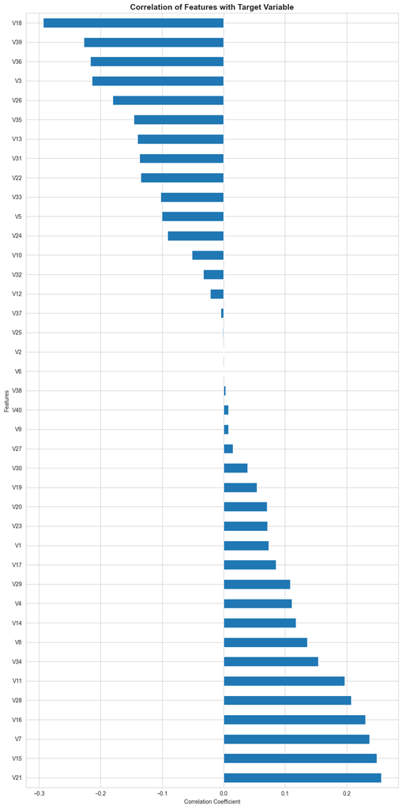

```
2. Feature Distribution by Target Class:
```

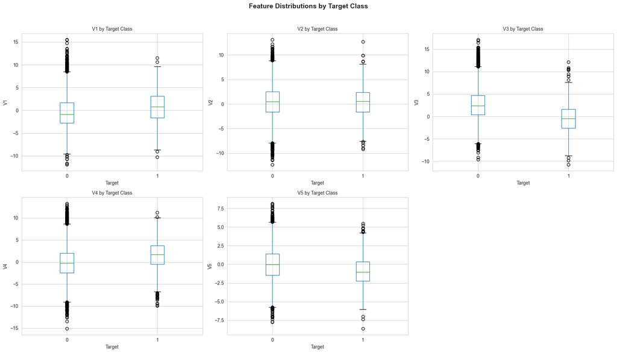

```
3. Density Plots for Key Features by Target Class:
```

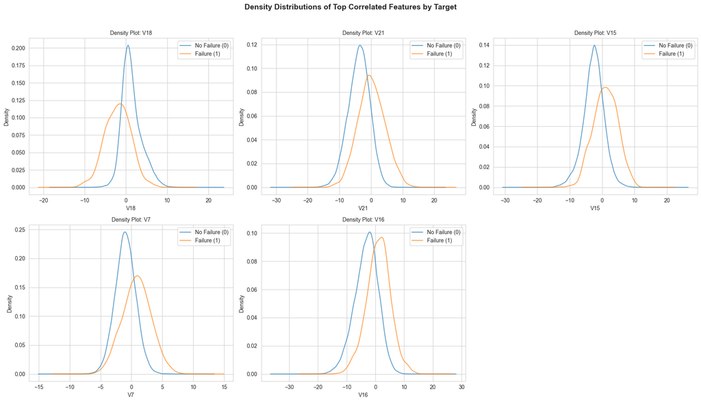

```
4. Correlation Heatmap for Top 15 Features (by absolute correlation with Target):
```

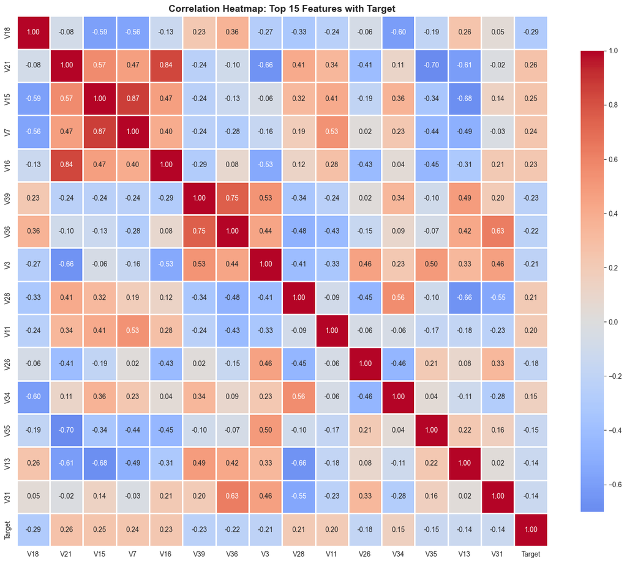

```
5. Mean Values of Features by Target Class (Top 10 Correlated Features):
     No Failure (0)  Failure (1)  Difference
V16       -3.161114     1.089148    4.250262
V21       -3.832999     0.162445    3.995444
V15       -2.617588     1.032767    3.650355
V36        1.714234    -1.879015   -3.593249
V18        1.373673    -1.947521   -3.321194
V3         2.660379    -0.505019   -3.165397
V11       -2.044374     0.639956    2.684329
V7        -0.980488     0.842285    1.822773
V39        0.987227    -0.752846   -1.740073
V28       -0.979610     0.757184    1.736794
```

```python
# BIVARIATE ANALYSIS

print("=" * 80)
print("BIVARIATE ANALYSIS")
print("=" * 80)

# Correlation analysis between features and target
print("\n1. Correlation Analysis with Target Variable:")
correlations = train_dataset.corr()['Target'].sort_values(ascending=False)
print("\nTop 10 Features Positively Correlated with Target:")
print(correlations.head(11)[1:])  # Exclude Target itself
print("\nTop 10 Features Negatively Correlated with Target:")
print(correlations.tail(10))

# Visualize correlation with target
plt.figure(figsize=(12, 8))
correlations_without_target = correlations.drop('Target')
correlations_without_target.plot(kind='barh', figsize=(10, 20))
plt.title('Correlation of Features with Target Variable', fontsize=14, fontweight='bold')
plt.xlabel('Correlation Coefficient')
plt.ylabel('Features')
plt.tight_layout()
plt.show()

# Feature distribution by target class
print("\n2. Feature Distribution by Target Class:")
sample_features = ['V1', 'V2', 'V3', 'V4', 'V5']

fig, axes = plt.subplots(2, 3, figsize=(18, 10))
axes = axes.ravel()

for idx, feature in enumerate(sample_features[:5]):
    train_dataset.boxplot(column=feature, by='Target', ax=axes[idx])
    axes[idx].set_title(f'{feature} by Target Class', fontsize=10)
    axes[idx].set_xlabel('Target')
    axes[idx].set_ylabel(feature)

# Remove empty subplot
fig.delaxes(axes[5])
plt.suptitle('Feature Distributions by Target Class', fontsize=14, fontweight='bold', y=1.02)
plt.tight_layout()
plt.show()

# Density plots for key features by target
print("\n3. Density Plots for Key Features by Target Class:")
key_features = correlations_without_target.abs().nlargest(5).index.tolist()

fig, axes = plt.subplots(2, 3, figsize=(18, 10))
axes = axes.ravel()

for idx, feature in enumerate(key_features[:5]):
    train_dataset[train_dataset['Target'] == 0][feature].plot(kind='density',
                                                               label='No Failure (0)',
                                                               ax=axes[idx],
                                                               alpha=0.7)
    train_dataset[train_dataset['Target'] == 1][feature].plot(kind='density',
                                                               label='Failure (1)',
                                                               ax=axes[idx],
                                                               alpha=0.7)
    axes[idx].set_title(f'Density Plot: {feature}', fontsize=10)
    axes[idx].set_xlabel(feature)
    axes[idx].set_ylabel('Density')
    axes[idx].legend()

# Remove empty subplot
fig.delaxes(axes[5])
plt.suptitle('Density Distributions of Top Correlated Features by Target',
             fontsize=14, fontweight='bold', y=1.02)
plt.tight_layout()
plt.show()

# Correlation heatmap for top correlated features
print("\n4. Correlation Heatmap for Top 15 Features (by absolute correlation with Target):")
top_features = correlations_without_target.abs().nlargest(15).index.tolist()
top_features.append('Target')  # Add target back

plt.figure(figsize=(14, 12))
correlation_matrix = train_dataset[top_features].corr()
sns.heatmap(correlation_matrix, annot=True, fmt='.2f', cmap='coolwarm',
            center=0, square=True, linewidths=1, cbar_kws={"shrink": 0.8})
plt.title('Correlation Heatmap: Top 15 Features with Target', fontsize=14, fontweight='bold')
plt.tight_layout()
plt.show()

# Statistical test: Mean difference by target class
print("\n5. Mean Values of Features by Target Class (Top 10 Correlated Features):")
top_10_features = correlations_without_target.abs().nlargest(10).index.tolist()
mean_comparison = pd.DataFrame({
    'No Failure (0)': train_dataset[train_dataset['Target'] == 0][top_10_features].mean(),
    'Failure (1)': train_dataset[train_dataset['Target'] == 1][top_10_features].mean()
})
mean_comparison['Difference'] = mean_comparison['Failure (1)'] - mean_comparison['No Failure (0)']
mean_comparison = mean_comparison.sort_values('Difference', key=abs, ascending=False)
print(mean_comparison)
```

# **Data Preprocessing**

```python
# DATA PREPROCESSING

print("=" * 80)
print("DATA PREPROCESSING")
print("=" * 80)

# Step 1: Handle Missing Values
print("\n1. Missing Value Treatment:")
print(f"Missing values before treatment: {train_dataset.isnull().sum().sum()}")

# Check which columns have missing values
missing_cols = train_dataset.columns[train_dataset.isnull().any()].tolist()
if len(missing_cols) > 0:
    print(f"Columns with missing values: {missing_cols}")
    print("\nMissing value counts per column:")
    print(train_dataset[missing_cols].isnull().sum())

    # Drop rows with missing values (as per standard practice for neural networks)
    train_dataset = train_dataset.dropna()
    print(f"\nAfter dropping rows with missing values: {train_dataset.shape[0]} rows remaining")
else:
    print("No missing values found in the dataset!")

# Step 2: Separate features and target
print("\n2. Separating Features and Target Variable:")
X = train_dataset.drop(['Target'], axis=1)
y = train_dataset['Target']

print(f"Features shape: {X.shape}")
print(f"Target shape: {y.shape}")
print(f"Target distribution:\n{y.value_counts()}")

# Step 3: Train-Validation Split (ensuring no data leakage)
print("\n3. Train-Validation Split (80-20 split):")
print("IMPORTANT: Splitting before any scaling to prevent data leakage!")

from sklearn.model_selection import train_test_split
X_train, X_val, y_train, y_val = train_test_split(X, y, test_size=0.2, random_state=42, stratify=y)

print(f"Training set shape: {X_train.shape}")
print(f"Validation set shape: {X_val.shape}")
print(f"\nTraining set target distribution:\n{y_train.value_counts()}")
print(f"\nValidation set target distribution:\n{y_val.value_counts()}")

# Step 4: Feature Scaling (Standardization)
print("\n4. Feature Scaling (Standardization):")
print("Applying StandardScaler to normalize features for neural network training")
print("Fitting scaler ONLY on training data to prevent data leakage!")

from sklearn.preprocessing import StandardScaler

scaler = StandardScaler()
X_train_scaled = scaler.fit_transform(X_train)
X_val_scaled = scaler.transform(X_val)

# Convert back to DataFrame for better readability
X_train_scaled = pd.DataFrame(X_train_scaled, columns=X.columns, index=X_train.index)
X_val_scaled = pd.DataFrame(X_val_scaled, columns=X.columns, index=X_val.index)

print("Scaling completed!")
print(f"\nTraining set statistics after scaling:")
print(f"Mean: {X_train_scaled.mean().mean():.6f} (should be ~0)")
print(f"Std: {X_train_scaled.std().mean():.6f} (should be ~1)")

# Step 5: Prepare test dataset (only scaling, no other preprocessing)
print("\n5. Preparing Test Dataset:")
print("Applying the SAME scaler fitted on training data to test data")

X_test = test_dataset.drop(['Target'], axis=1)
y_test = test_dataset['Target']
X_test_scaled = scaler.transform(X_test)
X_test_scaled = pd.DataFrame(X_test_scaled, columns=X.columns, index=X_test.index)

print(f"Test set shape: {X_test_scaled.shape}")
print(f"Test set target distribution:\n{y_test.value_counts()}")
```

```
================================================================================
DATA PREPROCESSING
================================================================================

1. Missing Value Treatment:
Missing values before treatment: 36
Columns with missing values: ['V1', 'V2']

Missing value counts per column:
V1    18
V2    18
dtype: int64

After dropping rows with missing values: 19964 rows remaining

2. Separating Features and Target Variable:
Features shape: (19964, 40)
Target shape: (19964,)
Target distribution:
Target
0    18854
1     1110
Name: count, dtype: int64

3. Train-Validation Split (80-20 split):
IMPORTANT: Splitting before any scaling to prevent data leakage!
Training set shape: (15971, 40)
Validation set shape: (3993, 40)

Training set target distribution:
Target
0    15083
1      888
Name: count, dtype: int64

Validation set target distribution:
Target
0    3771
1     222
Name: count, dtype: int64

4. Feature Scaling (Standardization):
Applying StandardScaler to normalize features for neural network training
Fitting scaler ONLY on training data to prevent data leakage!
Scaling completed!

Training set statistics after scaling:
Mean: 0.000000 (should be ~0)
Std: 1.000031 (should be ~1)

5. Preparing Test Dataset:
Applying the SAME scaler fitted on training data to test data
Test set shape: (5000, 40)
Test set target distribution:
Target
0    4718
1     282
Name: count, dtype: int64
```

# **Model Building**

## Model Evaluation Criterion

### Primary Metric: **F1-Score**

**Rationale:**

Given the business context of predictive maintenance for wind turbines, we need to balance the following cost considerations:

1. **True Positives (TP)**: Correctly predicted failures → Repair costs (lowest cost)
2. **False Negatives (FN)**: Missed failures → Replacement costs (highest cost - catastrophic)
3. **False Positives (FP)**: False alarms → Inspection costs (moderate cost)

**Why F1-Score?**

- **F1-Score** is the harmonic mean of Precision and Recall, providing a balanced metric
- **Precision** (TP/(TP+FP)): Important to minimize false alarms (inspection costs)
- **Recall** (TP/(TP+FN)): Critical to minimize missed failures (replacement costs are highest)
- F1-Score ensures we don't optimize for one at the expense of the other

**Additional Metrics for Comprehensive Evaluation:**

- **Accuracy**: Overall correctness, but can be misleading with class imbalance
- **Precision**: Minimize unnecessary inspections
- **Recall (Sensitivity)**: Critical - minimize missed failures
- **Specificity**: Ability to correctly identify non-failures
- **Confusion Matrix**: Visual representation of all prediction types
- **ROC-AUC**: Overall model discrimination ability

**Business Justification:**

Since replacement costs >> repair costs >> inspection costs, we prioritize:

1. **High Recall**: Catch as many real failures as possible (minimize FN)
2. **Reasonable Precision**: Avoid too many false alarms (minimize FP)
3. **F1-Score**: Balances both concerns optimally

This approach minimizes total maintenance costs while ensuring critical failures are detected.

## Initial Model Building (Model 0)

- Let's start with a neural network consisting of
  - just one hidden layer
  - activation function of ReLU
  - SGD as the optimizer

```
================================================================================
MODEL 0: Initial Neural Network
================================================================================
Architecture:
- Single hidden layer with 25 neurons
- ReLU activation function
- SGD optimizer
- Binary classification output

Model Architecture:
```

```
Model: "sequential"
```

```
┏━━━━━━━━━━━━━━━━━━━━━━━━━━━━━━━━━┳━━━━━━━━━━━━━━━━━━━━━━━━┳━━━━━━━━━━━━━━━┓
┃ Layer (type)                    ┃ Output Shape           ┃       Param # ┃
┡━━━━━━━━━━━━━━━━━━━━━━━━━━━━━━━━━╇━━━━━━━━━━━━━━━━━━━━━━━━╇━━━━━━━━━━━━━━━┩
│ hidden_layer_1 (Dense)          │ (None, 25)             │         1,025 │
├─────────────────────────────────┼────────────────────────┼───────────────┤
│ output_layer (Dense)            │ (None, 1)              │            26 │
└─────────────────────────────────┴────────────────────────┴───────────────┘
```

```
 Total params: 1,051 (4.11 KB)
```

```
 Trainable params: 1,051 (4.11 KB)
```

```
 Non-trainable params: 0 (0.00 B)
```

```
Training Model 0...
AttributeError: module 'ml_dtypes' has no attribute 'float4_e2m1fn'
500/500 ━━━━━━━━━━━━━━━━━━━━ 1s 1ms/step - accuracy: 0.9329 - auc: 0.7114 - loss: 0.2501 - precision: 0.2401 - recall: 0.0957 - val_accuracy: 0.9522 - val_auc: 0.8202 - val_loss: 0.1784 - val_precision: 0.9189 - val_recall: 0.1532
500/500 ━━━━━━━━━━━━━━━━━━━━ 0s 674us/step - accuracy: 0.9589 - auc: 0.8594 - loss: 0.1549 - precision: 0.9262 - recall: 0.2827 - val_accuracy: 0.9587 - val_auc: 0.8728 - val_loss: 0.1463 - val_precision: 0.9130 - val_recall: 0.2838
500/500 ━━━━━━━━━━━━━━━━━━━━ 0s 631us/step - accuracy: 0.9648 - auc: 0.8926 - loss: 0.1329 - precision: 0.9158 - recall: 0.4043 - val_accuracy: 0.9639 - val_auc: 0.8944 - val_loss: 0.1302 - val_precision: 0.9432 - val_recall: 0.3739
500/500 ━━━━━━━━━━━━━━━━━━━━ 0s 655us/step - accuracy: 0.9679 - auc: 0.9098 - loss: 0.1202 - precision: 0.9069 - recall: 0.4718 - val_accuracy: 0.9664 - val_auc: 0.9070 - val_loss: 0.1198 - val_precision: 0.9400 - val_recall: 0.4234
500/500 ━━━━━━━━━━━━━━━━━━━━ 0s 660us/step - accuracy: 0.9699 - auc: 0.9201 - loss: 0.1115 - precision: 0.9128 - recall: 0.5068 - val_accuracy: 0.9717 - val_auc: 0.9151 - val_loss: 0.1120 - val_precision: 0.9431 - val_recall: 0.5225
500/500 ━━━━━━━━━━━━━━━━━━━━ 0s 637us/step - accuracy: 0.9719 - auc: 0.9276 - loss: 0.1050 - precision: 0.9120 - recall: 0.5484 - val_accuracy: 0.9725 - val_auc: 0.9203 - val_loss: 0.1063 - val_precision: 0.9590 - val_recall: 0.5270
500/500 ━━━━━━━━━━━━━━━━━━━━ 0s 661us/step - accuracy: 0.9736 - auc: 0.9330 - loss: 0.0996 - precision: 0.9300 - recall: 0.5687 - val_accuracy: 0.9742 - val_auc: 0.9260 - val_loss: 0.1016 - val_precision: 0.9685 - val_recall: 0.5541
500/500 ━━━━━━━━━━━━━━━━━━━━ 0s 720us/step - accuracy: 0.9751 - auc: 0.9360 - loss: 0.0953 - precision: 0.9408 - recall: 0.5901 - val_accuracy: 0.9750 - val_auc: 0.9293 - val_loss: 0.0975 - val_precision: 0.9692 - val_recall: 0.5676
500/500 ━━━━━━━━━━━━━━━━━━━━ 0s 649us/step - accuracy: 0.9760 - auc: 0.9391 - loss: 0.0914 - precision: 0.9452 - recall: 0.6025 - val_accuracy: 0.9765 - val_auc: 0.9317 - val_loss: 0.0941 - val_precision: 0.9776 - val_recall: 0.5901
500/500 ━━━━━━━━━━━━━━━━━━━━ 0s 686us/step - accuracy: 0.9770 - auc: 0.9409 - loss: 0.0880 - precision: 0.9530 - recall: 0.6160 - val_accuracy: 0.9777 - val_auc: 0.9341 - val_loss: 0.0906 - val_precision: 0.9716 - val_recall: 0.6171
500/500 ━━━━━━━━━━━━━━━━━━━━ 0s 634us/step - accuracy: 0.9785 - auc: 0.9428 - loss: 0.0850 - precision: 0.9626 - recall: 0.6374 - val_accuracy: 0.9792 - val_auc: 0.9360 - val_loss: 0.0877 - val_precision: 0.9664 - val_recall: 0.6486
500/500 ━━━━━━━━━━━━━━━━━━━━ 0s 668us/step - accuracy: 0.9795 - auc: 0.9442 - loss: 0.0824 - precision: 0.9667 - recall: 0.6543 - val_accuracy: 0.9797 - val_auc: 0.9366 - val_loss: 0.0853 - val_precision: 0.9796 - val_recall: 0.6486
500/500 ━━━━━━━━━━━━━━━━━━━━ 0s 616us/step - accuracy: 0.9805 - auc: 0.9460 - loss: 0.0800 - precision: 0.9645 - recall: 0.6734 - val_accuracy: 0.9802 - val_auc: 0.9377 - val_loss: 0.0833 - val_precision: 0.9799 - val_recall: 0.6577
500/500 ━━━━━━━━━━━━━━━━━━━━ 0s 626us/step - accuracy: 0.9814 - auc: 0.9463 - loss: 0.0779 - precision: 0.9713 - recall: 0.6858 - val_accuracy: 0.9812 - val_auc: 0.9388 - val_loss: 0.0812 - val_precision: 0.9804 - val_recall: 0.6757
500/500 ━━━━━━━━━━━━━━━━━━━━ 0s 735us/step - accuracy: 0.9821 - auc: 0.9466 - loss: 0.0761 - precision: 0.9703 - recall: 0.6993 - val_accuracy: 0.9812 - val_auc: 0.9392 - val_loss: 0.0798 - val_precision: 0.9804 - val_recall: 0.6757
500/500 ━━━━━━━━━━━━━━━━━━━━ 0s 669us/step - accuracy: 0.9826 - auc: 0.9475 - loss: 0.0745 - precision: 0.9781 - recall: 0.7027 - val_accuracy: 0.9812 - val_auc: 0.9417 - val_loss: 0.0775 - val_precision: 0.9682 - val_recall: 0.6847
500/500 ━━━━━━━━━━━━━━━━━━━━ 0s 647us/step - accuracy: 0.9835 - auc: 0.9489 - loss: 0.0730 - precision: 0.9771 - recall: 0.7207 - val_accuracy: 0.9815 - val_auc: 0.9416 - val_loss: 0.0763 - val_precision: 0.9684 - val_recall: 0.6892
500/500 ━━━━━━━━━━━━━━━━━━━━ 0s 659us/step - accuracy: 0.9834 - auc: 0.9487 - loss: 0.0717 - precision: 0.9741 - recall: 0.7207 - val_accuracy: 0.9812 - val_auc: 0.9424 - val_loss: 0.0752 - val_precision: 0.9742 - val_recall: 0.6802
500/500 ━━━━━━━━━━━━━━━━━━━━ 0s 696us/step - accuracy: 0.9843 - auc: 0.9490 - loss: 0.0706 - precision: 0.9804 - recall: 0.7320 - val_accuracy: 0.9820 - val_auc: 0.9430 - val_loss: 0.0739 - val_precision: 0.9747 - val_recall: 0.6937
500/500 ━━━━━━━━━━━━━━━━━━━━ 0s 661us/step - accuracy: 0.9846 - auc: 0.9491 - loss: 0.0695 - precision: 0.9805 - recall: 0.7376 - val_accuracy: 0.9835 - val_auc: 0.9432 - val_loss: 0.0725 - val_precision: 0.9756 - val_recall: 0.7207
500/500 ━━━━━━━━━━━━━━━━━━━━ 0s 647us/step - accuracy: 0.9849 - auc: 0.9489 - loss: 0.0685 - precision: 0.9793 - recall: 0.7444 - val_accuracy: 0.9830 - val_auc: 0.9439 - val_loss: 0.0715 - val_precision: 0.9753 - val_recall: 0.7117
500/500 ━━━━━━━━━━━━━━━━━━━━ 0s 634us/step - accuracy: 0.9853 - auc: 0.9496 - loss: 0.0676 - precision: 0.9809 - recall: 0.7511 - val_accuracy: 0.9832 - val_auc: 0.9448 - val_loss: 0.0709 - val_precision: 0.9814 - val_recall: 0.7117
500/500 ━━━━━━━━━━━━━━━━━━━━ 0s 619us/step - accuracy: 0.9851 - auc: 0.9496 - loss: 0.0668 - precision: 0.9794 - recall: 0.7477 - val_accuracy: 0.9832 - val_auc: 0.9453 - val_loss: 0.0696 - val_precision: 0.9755 - val_recall: 0.7162
500/500 ━━━━━━━━━━━━━━━━━━━━ 0s 723us/step - accuracy: 0.9853 - auc: 0.9496 - loss: 0.0661 - precision: 0.9780 - recall: 0.7523 - val_accuracy: 0.9835 - val_auc: 0.9455 - val_loss: 0.0689 - val_precision: 0.9756 - val_recall: 0.7207
```

[output cut: 50 more lines]

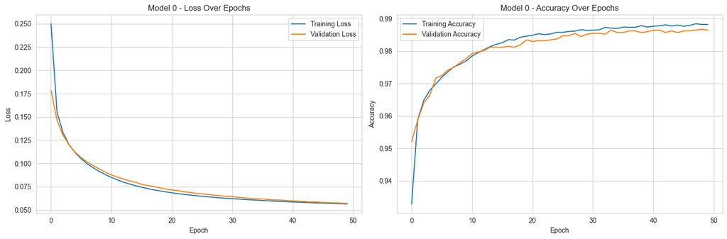

```
================================================================================
MODEL 0 PERFORMANCE SUMMARY:
================================================================================
F1-Score: 0.8636
Recall: 0.7703
Precision: 0.9828
AUC: 0.9533
```

```python
# MODEL 0: Initial Neural Network with SGD Optimizer

print("=" * 80)
print("MODEL 0: Initial Neural Network")
print("=" * 80)
print("Architecture:")
print("- Single hidden layer with 25 neurons")
print("- ReLU activation function")
print("- SGD optimizer")
print("- Binary classification output")

# Clear any previous models
tf.keras.backend.clear_session()

# Build the model
model0 = Sequential([
    Dense(25, activation='relu', input_dim=X_train_scaled.shape[1], name='hidden_layer_1'),
    Dense(1, activation='sigmoid', name='output_layer')  # Sigmoid for binary classification
])

# Display model architecture
print("\nModel Architecture:")
model0.summary()

# Compile the model
optimizer0 = keras.optimizers.SGD(learning_rate=0.01)
model0.compile(
    optimizer=optimizer0,
    loss='binary_crossentropy',  # Appropriate for binary classification
    metrics=['accuracy',
             tf.keras.metrics.Precision(name='precision'),
             tf.keras.metrics.Recall(name='recall'),
             tf.keras.metrics.AUC(name='auc')]
)

# Train the model
print("\nTraining Model 0...")
epochs = 50
batch_size = 32

history0 = model0.fit(
    X_train_scaled, y_train,
    batch_size=batch_size,
    epochs=epochs,
    validation_data=(X_val_scaled, y_val),
    verbose=1
)

# Evaluate on validation set
print("\n" + "=" * 80)
print("MODEL 0 - Validation Set Performance:")
print("=" * 80)
val_loss, val_accuracy, val_precision, val_recall, val_auc = model0.evaluate(
    X_val_scaled, y_val, verbose=0
)

# Calculate F1-Score
val_f1 = 2 * (val_precision * val_recall) / (val_precision + val_recall)

print(f"Validation Loss: {val_loss:.4f}")
print(f"Validation Accuracy: {val_accuracy:.4f}")
print(f"Validation Precision: {val_precision:.4f}")
print(f"Validation Recall: {val_recall:.4f}")
print(f"Validation F1-Score: {val_f1:.4f}")
print(f"Validation AUC: {val_auc:.4f}")

# Predictions for confusion matrix
y_val_pred_proba = model0.predict(X_val_scaled, verbose=0)
y_val_pred = (y_val_pred_proba > 0.5).astype(int).flatten()

# Confusion Matrix
from sklearn.metrics import confusion_matrix, classification_report
cm0 = confusion_matrix(y_val, y_val_pred)
print("\nConfusion Matrix:")
print(cm0)
print("\nClassification Report:")
print(classification_report(y_val, y_val_pred, target_names=['No Failure', 'Failure']))

# Plot training history
fig, axes = plt.subplots(1, 2, figsize=(15, 5))

# Loss plot
axes[0].plot(history0.history['loss'], label='Training Loss')
axes[0].plot(history0.history['val_loss'], label='Validation Loss')
axes[0].set_title('Model 0 - Loss Over Epochs')
axes[0].set_xlabel('Epoch')
axes[0].set_ylabel('Loss')
axes[0].legend()
axes[0].grid(True)

# Accuracy plot
axes[1].plot(history0.history['accuracy'], label='Training Accuracy')
axes[1].plot(history0.history['val_accuracy'], label='Validation Accuracy')
axes[1].set_title('Model 0 - Accuracy Over Epochs')
axes[1].set_xlabel('Epoch')
axes[1].set_ylabel('Accuracy')
axes[1].legend()
axes[1].grid(True)

plt.tight_layout()
plt.show()

# Store model performance
model0_performance = {
    'model': 'Model 0',
    'architecture': 'Single hidden layer (25 neurons, ReLU)',
    'optimizer': 'SGD',
    'val_loss': val_loss,
    'val_accuracy': val_accuracy,
    'val_precision': val_precision,
    'val_recall': val_recall,
    'val_f1': val_f1,
    'val_auc': val_auc
}

print("\n" + "=" * 80)
print("MODEL 0 PERFORMANCE SUMMARY:")
print("=" * 80)
print(f"F1-Score: {val_f1:.4f}")
print(f"Recall: {val_recall:.4f}")
print(f"Precision: {val_precision:.4f}")
print(f"AUC: {val_auc:.4f}")
```

# **Model Performance Improvement**

## Model 1

```python
# MODEL 1: Multiple Hidden Layers with SGD Optimizer

print("=" * 80)
print("MODEL 1: Multiple Hidden Layers with SGD")
print("=" * 80)
print("Architecture:")
print("- Two hidden layers (50, 25 neurons)")
print("- ReLU activation function")
print("- SGD optimizer")
print("- No dropout, no class weights")

tf.keras.backend.clear_session()

# Build the model
model1 = Sequential([
    Dense(50, activation='relu', input_dim=X_train_scaled.shape[1], name='hidden_layer_1'),
    Dense(25, activation='relu', name='hidden_layer_2'),
    Dense(1, activation='sigmoid', name='output_layer')
])

print("\nModel Architecture:")
model1.summary()

# Compile the model
optimizer1 = keras.optimizers.SGD(learning_rate=0.01)
model1.compile(
    optimizer=optimizer1,
    loss='binary_crossentropy',
    metrics=['accuracy',
             tf.keras.metrics.Precision(name='precision'),
             tf.keras.metrics.Recall(name='recall'),
             tf.keras.metrics.AUC(name='auc')]
)

# Train the model
print("\nTraining Model 1...")
epochs = 50
batch_size = 32

history1 = model1.fit(
    X_train_scaled, y_train,
    batch_size=batch_size,
    epochs=epochs,
    validation_data=(X_val_scaled, y_val),
    verbose=1
)

# Evaluate on validation set
print("\n" + "=" * 80)
print("MODEL 1 - Validation Set Performance:")
print("=" * 80)
val_loss, val_accuracy, val_precision, val_recall, val_auc = model1.evaluate(
    X_val_scaled, y_val, verbose=0
)

val_f1 = 2 * (val_precision * val_recall) / (val_precision + val_recall)

print(f"Validation Loss: {val_loss:.4f}")
print(f"Validation Accuracy: {val_accuracy:.4f}")
print(f"Validation Precision: {val_precision:.4f}")
print(f"Validation Recall: {val_recall:.4f}")
print(f"Validation F1-Score: {val_f1:.4f}")
print(f"Validation AUC: {val_auc:.4f}")

# Predictions
y_val_pred_proba = model1.predict(X_val_scaled, verbose=0)
y_val_pred = (y_val_pred_proba > 0.5).astype(int).flatten()

# Confusion Matrix
from sklearn.metrics import confusion_matrix, classification_report
cm1 = confusion_matrix(y_val, y_val_pred)
print("\nConfusion Matrix:")
print(cm1)
print("\nClassification Report:")
print(classification_report(y_val, y_val_pred, target_names=['No Failure', 'Failure']))

# Store model performance
model1_performance = {
    'model': 'Model 1',
    'architecture': 'Two hidden layers (50, 25 neurons, ReLU)',
    'optimizer': 'SGD',
    'dropout': 'No',
    'class_weights': 'No',
    'val_loss': val_loss,
    'val_accuracy': val_accuracy,
    'val_precision': val_precision,
    'val_recall': val_recall,
    'val_f1': val_f1,
    'val_auc': val_auc
}

print("\n" + "=" * 80)
print("MODEL 1 PERFORMANCE SUMMARY:")
print("=" * 80)
print(f"F1-Score: {val_f1:.4f} (Primary Metric)")
print(f"Recall: {val_recall:.4f}")
print(f"Precision: {val_precision:.4f}")
print(f"AUC: {val_auc:.4f}")
print("\nComment: Adding more hidden layers increased model capacity, allowing it to learn more complex patterns.")
```

```
================================================================================
MODEL 1: Multiple Hidden Layers with SGD
================================================================================
Architecture:
- Two hidden layers (50, 25 neurons)
- ReLU activation function
- SGD optimizer
- No dropout, no class weights

Model Architecture:
```

```
Model: "sequential"
```

```
┏━━━━━━━━━━━━━━━━━━━━━━━━━━━━━━━━━┳━━━━━━━━━━━━━━━━━━━━━━━━┳━━━━━━━━━━━━━━━┓
┃ Layer (type)                    ┃ Output Shape           ┃       Param # ┃
┡━━━━━━━━━━━━━━━━━━━━━━━━━━━━━━━━━╇━━━━━━━━━━━━━━━━━━━━━━━━╇━━━━━━━━━━━━━━━┩
│ hidden_layer_1 (Dense)          │ (None, 50)             │         2,050 │
├─────────────────────────────────┼────────────────────────┼───────────────┤
│ hidden_layer_2 (Dense)          │ (None, 25)             │         1,275 │
├─────────────────────────────────┼────────────────────────┼───────────────┤
│ output_layer (Dense)            │ (None, 1)              │            26 │
└─────────────────────────────────┴────────────────────────┴───────────────┘
```

```
 Total params: 3,351 (13.09 KB)
```

```
 Trainable params: 3,351 (13.09 KB)
```

```
 Non-trainable params: 0 (0.00 B)
```

```
Training Model 1...
500/500 ━━━━━━━━━━━━━━━━━━━━ 1s 1ms/step - accuracy: 0.9400 - auc: 0.7207 - loss: 0.2198 - precision: 0.3234 - recall: 0.0732 - val_accuracy: 0.9557 - val_auc: 0.8381 - val_loss: 0.1579 - val_precision: 0.9787 - val_recall: 0.2072
500/500 ━━━━━━━━━━━━━━━━━━━━ 0s 701us/step - accuracy: 0.9646 - auc: 0.8935 - loss: 0.1309 - precision: 0.9708 - recall: 0.3739 - val_accuracy: 0.9667 - val_auc: 0.9002 - val_loss: 0.1203 - val_precision: 0.9785 - val_recall: 0.4099
500/500 ━━━━━━━━━━━━━━━━━━━━ 0s 723us/step - accuracy: 0.9723 - auc: 0.9217 - loss: 0.1073 - precision: 0.9459 - recall: 0.5315 - val_accuracy: 0.9745 - val_auc: 0.9205 - val_loss: 0.1023 - val_precision: 0.9615 - val_recall: 0.5631
500/500 ━━━━━━━━━━━━━━━━━━━━ 0s 651us/step - accuracy: 0.9765 - auc: 0.9330 - loss: 0.0946 - precision: 0.9571 - recall: 0.6036 - val_accuracy: 0.9777 - val_auc: 0.9323 - val_loss: 0.0911 - val_precision: 0.9650 - val_recall: 0.6216
500/500 ━━━━━━━━━━━━━━━━━━━━ 0s 708us/step - accuracy: 0.9790 - auc: 0.9404 - loss: 0.0854 - precision: 0.9555 - recall: 0.6532 - val_accuracy: 0.9800 - val_auc: 0.9372 - val_loss: 0.0833 - val_precision: 0.9797 - val_recall: 0.6532
500/500 ━━━━━━━━━━━━━━━━━━━━ 0s 666us/step - accuracy: 0.9817 - auc: 0.9441 - loss: 0.0784 - precision: 0.9760 - recall: 0.6869 - val_accuracy: 0.9825 - val_auc: 0.9419 - val_loss: 0.0768 - val_precision: 0.9810 - val_recall: 0.6982
500/500 ━━━━━━━━━━━━━━━━━━━━ 0s 660us/step - accuracy: 0.9835 - auc: 0.9464 - loss: 0.0730 - precision: 0.9786 - recall: 0.7196 - val_accuracy: 0.9842 - val_auc: 0.9449 - val_loss: 0.0716 - val_precision: 0.9818 - val_recall: 0.7297
500/500 ━━━━━━━━━━━━━━━━━━━━ 0s 665us/step - accuracy: 0.9853 - auc: 0.9479 - loss: 0.0688 - precision: 0.9823 - recall: 0.7500 - val_accuracy: 0.9847 - val_auc: 0.9460 - val_loss: 0.0678 - val_precision: 0.9820 - val_recall: 0.7387
500/500 ━━━━━━━━━━━━━━━━━━━━ 0s 626us/step - accuracy: 0.9860 - auc: 0.9498 - loss: 0.0656 - precision: 0.9854 - recall: 0.7590 - val_accuracy: 0.9857 - val_auc: 0.9479 - val_loss: 0.0644 - val_precision: 0.9825 - val_recall: 0.7568
500/500 ━━━━━━━━━━━━━━━━━━━━ 0s 631us/step - accuracy: 0.9870 - auc: 0.9514 - loss: 0.0629 - precision: 0.9899 - recall: 0.7748 - val_accuracy: 0.9855 - val_auc: 0.9500 - val_loss: 0.0621 - val_precision: 0.9824 - val_recall: 0.7523
500/500 ━━━━━━━━━━━━━━━━━━━━ 0s 633us/step - accuracy: 0.9872 - auc: 0.9522 - loss: 0.0609 - precision: 0.9858 - recall: 0.7815 - val_accuracy: 0.9877 - val_auc: 0.9495 - val_loss: 0.0594 - val_precision: 0.9832 - val_recall: 0.7928
500/500 ━━━━━━━━━━━━━━━━━━━━ 0s 628us/step - accuracy: 0.9879 - auc: 0.9519 - loss: 0.0591 - precision: 0.9860 - recall: 0.7939 - val_accuracy: 0.9887 - val_auc: 0.9492 - val_loss: 0.0577 - val_precision: 0.9836 - val_recall: 0.8108
500/500 ━━━━━━━━━━━━━━━━━━━━ 0s 630us/step - accuracy: 0.9881 - auc: 0.9536 - loss: 0.0577 - precision: 0.9820 - recall: 0.8007 - val_accuracy: 0.9880 - val_auc: 0.9509 - val_loss: 0.0560 - val_precision: 0.9833 - val_recall: 0.7973
500/500 ━━━━━━━━━━━━━━━━━━━━ 0s 634us/step - accuracy: 0.9889 - auc: 0.9527 - loss: 0.0563 - precision: 0.9890 - recall: 0.8086 - val_accuracy: 0.9880 - val_auc: 0.9522 - val_loss: 0.0545 - val_precision: 0.9833 - val_recall: 0.7973
500/500 ━━━━━━━━━━━━━━━━━━━━ 0s 635us/step - accuracy: 0.9889 - auc: 0.9539 - loss: 0.0552 - precision: 0.9850 - recall: 0.8119 - val_accuracy: 0.9880 - val_auc: 0.9512 - val_loss: 0.0538 - val_precision: 0.9833 - val_recall: 0.7973
500/500 ━━━━━━━━━━━━━━━━━━━━ 0s 633us/step - accuracy: 0.9887 - auc: 0.9541 - loss: 0.0542 - precision: 0.9849 - recall: 0.8086 - val_accuracy: 0.9892 - val_auc: 0.9538 - val_loss: 0.0521 - val_precision: 0.9838 - val_recall: 0.8198
500/500 ━━━━━━━━━━━━━━━━━━━━ 0s 643us/step - accuracy: 0.9893 - auc: 0.9565 - loss: 0.0533 - precision: 0.9864 - recall: 0.8187 - val_accuracy: 0.9890 - val_auc: 0.9543 - val_loss: 0.0516 - val_precision: 0.9837 - val_recall: 0.8153
500/500 ━━━━━━━━━━━━━━━━━━━━ 0s 747us/step - accuracy: 0.9897 - auc: 0.9552 - loss: 0.0525 - precision: 0.9853 - recall: 0.8277 - val_accuracy: 0.9892 - val_auc: 0.9572 - val_loss: 0.0506 - val_precision: 0.9838 - val_recall: 0.8198
500/500 ━━━━━━━━━━━━━━━━━━━━ 0s 734us/step - accuracy: 0.9896 - auc: 0.9570 - loss: 0.0518 - precision: 0.9839 - recall: 0.8266 - val_accuracy: 0.9907 - val_auc: 0.9561 - val_loss: 0.0495 - val_precision: 0.9843 - val_recall: 0.8468
500/500 ━━━━━━━━━━━━━━━━━━━━ 0s 714us/step - accuracy: 0.9900 - auc: 0.9559 - loss: 0.0510 - precision: 0.9866 - recall: 0.8311 - val_accuracy: 0.9907 - val_auc: 0.9569 - val_loss: 0.0492 - val_precision: 0.9843 - val_recall: 0.8468
500/500 ━━━━━━━━━━━━━━━━━━━━ 0s 725us/step - accuracy: 0.9900 - auc: 0.9575 - loss: 0.0505 - precision: 0.9840 - recall: 0.8333 - val_accuracy: 0.9900 - val_auc: 0.9570 - val_loss: 0.0488 - val_precision: 0.9892 - val_recall: 0.8288
500/500 ━━━━━━━━━━━━━━━━━━━━ 0s 733us/step - accuracy: 0.9898 - auc: 0.9579 - loss: 0.0500 - precision: 0.9840 - recall: 0.8300 - val_accuracy: 0.9900 - val_auc: 0.9557 - val_loss: 0.0481 - val_precision: 0.9840 - val_recall: 0.8333
500/500 ━━━━━━━━━━━━━━━━━━━━ 0s 703us/step - accuracy: 0.9901 - auc: 0.9583 - loss: 0.0494 - precision: 0.9880 - recall: 0.8322 - val_accuracy: 0.9917 - val_auc: 0.9543 - val_loss: 0.0473 - val_precision: 0.9846 - val_recall: 0.8649
500/500 ━━━━━━━━━━━━━━━━━━━━ 0s 695us/step - accuracy: 0.9900 - auc: 0.9570 - loss: 0.0488 - precision: 0.9840 - recall: 0.8333 - val_accuracy: 0.9917 - val_auc: 0.9544 - val_loss: 0.0469 - val_precision: 0.9846 - val_recall: 0.8649
500/500 ━━━━━━━━━━━━━━━━━━━━ 0s 709us/step - accuracy: 0.9900 - auc: 0.9582 - loss: 0.0484 - precision: 0.9854 - recall: 0.8333 - val_accuracy: 0.9910 - val_auc: 0.9555 - val_loss: 0.0465 - val_precision: 0.9844 - val_recall: 0.8514
```

[output cut: 60 more lines]

## Model 2

```python
# MODEL 2: Multiple Hidden Layers with Adam Optimizer

print("=" * 80)
print("MODEL 2: Multiple Hidden Layers with Adam Optimizer")
print("=" * 80)
print("Architecture:")
print("- Two hidden layers (50, 25 neurons)")
print("- ReLU activation function")
print("- Adam optimizer (adaptive learning rate)")
print("- No dropout, no class weights")

tf.keras.backend.clear_session()

# Build the model
model2 = Sequential([
    Dense(50, activation='relu', input_dim=X_train_scaled.shape[1], name='hidden_layer_1'),
    Dense(25, activation='relu', name='hidden_layer_2'),
    Dense(1, activation='sigmoid', name='output_layer')
])

print("\nModel Architecture:")
model2.summary()

# Compile the model with Adam optimizer
optimizer2 = keras.optimizers.Adam(learning_rate=0.001)
model2.compile(
    optimizer=optimizer2,
    loss='binary_crossentropy',
    metrics=['accuracy',
             tf.keras.metrics.Precision(name='precision'),
             tf.keras.metrics.Recall(name='recall'),
             tf.keras.metrics.AUC(name='auc')]
)

# Train the model
print("\nTraining Model 2...")
epochs = 50
batch_size = 32

history2 = model2.fit(
    X_train_scaled, y_train,
    batch_size=batch_size,
    epochs=epochs,
    validation_data=(X_val_scaled, y_val),
    verbose=1
)

# Evaluate on validation set
print("\n" + "=" * 80)
print("MODEL 2 - Validation Set Performance:")
print("=" * 80)
val_loss, val_accuracy, val_precision, val_recall, val_auc = model2.evaluate(
    X_val_scaled, y_val, verbose=0
)

val_f1 = 2 * (val_precision * val_recall) / (val_precision + val_recall)

print(f"Validation Loss: {val_loss:.4f}")
print(f"Validation Accuracy: {val_accuracy:.4f}")
print(f"Validation Precision: {val_precision:.4f}")
print(f"Validation Recall: {val_recall:.4f}")
print(f"Validation F1-Score: {val_f1:.4f}")
print(f"Validation AUC: {val_auc:.4f}")

# Predictions
y_val_pred_proba = model2.predict(X_val_scaled, verbose=0)
y_val_pred = (y_val_pred_proba > 0.5).astype(int).flatten()

# Confusion Matrix
cm2 = confusion_matrix(y_val, y_val_pred)
print("\nConfusion Matrix:")
print(cm2)
print("\nClassification Report:")
print(classification_report(y_val, y_val_pred, target_names=['No Failure', 'Failure']))

# Store model performance
model2_performance = {
    'model': 'Model 2',
    'architecture': 'Two hidden layers (50, 25 neurons, ReLU)',
    'optimizer': 'Adam',
    'dropout': 'No',
    'class_weights': 'No',
    'val_loss': val_loss,
    'val_accuracy': val_accuracy,
    'val_precision': val_precision,
    'val_recall': val_recall,
    'val_f1': val_f1,
    'val_auc': val_auc
}

print("\n" + "=" * 80)
print("MODEL 2 PERFORMANCE SUMMARY:")
print("=" * 80)
print(f"F1-Score: {val_f1:.4f} (Primary Metric)")
print(f"Recall: {val_recall:.4f}")
print(f"Precision: {val_precision:.4f}")
print(f"AUC: {val_auc:.4f}")
print("\nComment: Adam optimizer adapts learning rates per parameter, often leading to faster convergence and better performance than SGD.")
```

```
================================================================================
MODEL 2: Multiple Hidden Layers with Adam Optimizer
================================================================================
Architecture:
- Two hidden layers (50, 25 neurons)
- ReLU activation function
- Adam optimizer (adaptive learning rate)
- No dropout, no class weights

Model Architecture:
```

```
Model: "sequential"
```

```
┏━━━━━━━━━━━━━━━━━━━━━━━━━━━━━━━━━┳━━━━━━━━━━━━━━━━━━━━━━━━┳━━━━━━━━━━━━━━━┓
┃ Layer (type)                    ┃ Output Shape           ┃       Param # ┃
┡━━━━━━━━━━━━━━━━━━━━━━━━━━━━━━━━━╇━━━━━━━━━━━━━━━━━━━━━━━━╇━━━━━━━━━━━━━━━┩
│ hidden_layer_1 (Dense)          │ (None, 50)             │         2,050 │
├─────────────────────────────────┼────────────────────────┼───────────────┤
│ hidden_layer_2 (Dense)          │ (None, 25)             │         1,275 │
├─────────────────────────────────┼────────────────────────┼───────────────┤
│ output_layer (Dense)            │ (None, 1)              │            26 │
└─────────────────────────────────┴────────────────────────┴───────────────┘
```

```
 Total params: 3,351 (13.09 KB)
```

```
 Trainable params: 3,351 (13.09 KB)
```

```
 Non-trainable params: 0 (0.00 B)
```

```
Training Model 2...
500/500 ━━━━━━━━━━━━━━━━━━━━ 1s 995us/step - accuracy: 0.9705 - auc: 0.9154 - loss: 0.1183 - precision: 0.9049 - recall: 0.5248 - val_accuracy: 0.9840 - val_auc: 0.9447 - val_loss: 0.0736 - val_precision: 0.9817 - val_recall: 0.7252
500/500 ━━━━━━━━━━━━━━━━━━━━ 0s 676us/step - accuracy: 0.9869 - auc: 0.9504 - loss: 0.0647 - precision: 0.9696 - recall: 0.7894 - val_accuracy: 0.9897 - val_auc: 0.9569 - val_loss: 0.0526 - val_precision: 0.9892 - val_recall: 0.8243
500/500 ━━━━━━━━━━━━━━━━━━━━ 0s 689us/step - accuracy: 0.9895 - auc: 0.9542 - loss: 0.0545 - precision: 0.9749 - recall: 0.8322 - val_accuracy: 0.9925 - val_auc: 0.9569 - val_loss: 0.0460 - val_precision: 0.9800 - val_recall: 0.8829
500/500 ━━━━━━━━━━━━━━━━━━━━ 0s 693us/step - accuracy: 0.9905 - auc: 0.9565 - loss: 0.0496 - precision: 0.9804 - recall: 0.8468 - val_accuracy: 0.9917 - val_auc: 0.9566 - val_loss: 0.0443 - val_precision: 0.9846 - val_recall: 0.8649
500/500 ━━━━━━━━━━━━━━━━━━━━ 0s 671us/step - accuracy: 0.9906 - auc: 0.9619 - loss: 0.0462 - precision: 0.9755 - recall: 0.8525 - val_accuracy: 0.9932 - val_auc: 0.9585 - val_loss: 0.0412 - val_precision: 0.9949 - val_recall: 0.8829
500/500 ━━━━━━━━━━━━━━━━━━━━ 0s 674us/step - accuracy: 0.9915 - auc: 0.9624 - loss: 0.0440 - precision: 0.9796 - recall: 0.8649 - val_accuracy: 0.9930 - val_auc: 0.9630 - val_loss: 0.0398 - val_precision: 0.9802 - val_recall: 0.8919
500/500 ━━━━━━━━━━━━━━━━━━━━ 0s 674us/step - accuracy: 0.9919 - auc: 0.9623 - loss: 0.0427 - precision: 0.9797 - recall: 0.8716 - val_accuracy: 0.9935 - val_auc: 0.9611 - val_loss: 0.0387 - val_precision: 0.9900 - val_recall: 0.8919
500/500 ━━━━━━━━━━━━━━━━━━━━ 0s 674us/step - accuracy: 0.9920 - auc: 0.9671 - loss: 0.0408 - precision: 0.9822 - recall: 0.8716 - val_accuracy: 0.9927 - val_auc: 0.9672 - val_loss: 0.0370 - val_precision: 0.9849 - val_recall: 0.8829
500/500 ━━━━━━━━━━━━━━━━━━━━ 0s 677us/step - accuracy: 0.9921 - auc: 0.9673 - loss: 0.0403 - precision: 0.9739 - recall: 0.8818 - val_accuracy: 0.9927 - val_auc: 0.9651 - val_loss: 0.0376 - val_precision: 0.9849 - val_recall: 0.8829
500/500 ━━━━━━━━━━━━━━━━━━━━ 0s 727us/step - accuracy: 0.9924 - auc: 0.9684 - loss: 0.0385 - precision: 0.9812 - recall: 0.8806 - val_accuracy: 0.9940 - val_auc: 0.9609 - val_loss: 0.0365 - val_precision: 0.9950 - val_recall: 0.8964
500/500 ━━━━━━━━━━━━━━━━━━━━ 0s 761us/step - accuracy: 0.9930 - auc: 0.9696 - loss: 0.0370 - precision: 0.9862 - recall: 0.8874 - val_accuracy: 0.9937 - val_auc: 0.9670 - val_loss: 0.0360 - val_precision: 0.9852 - val_recall: 0.9009
500/500 ━━━━━━━━━━━━━━━━━━━━ 0s 766us/step - accuracy: 0.9926 - auc: 0.9680 - loss: 0.0372 - precision: 0.9789 - recall: 0.8863 - val_accuracy: 0.9940 - val_auc: 0.9614 - val_loss: 0.0369 - val_precision: 0.9950 - val_recall: 0.8964
500/500 ━━━━━━━━━━━━━━━━━━━━ 0s 776us/step - accuracy: 0.9925 - auc: 0.9724 - loss: 0.0362 - precision: 0.9824 - recall: 0.8818 - val_accuracy: 0.9935 - val_auc: 0.9681 - val_loss: 0.0357 - val_precision: 0.9851 - val_recall: 0.8964
500/500 ━━━━━━━━━━━━━━━━━━━━ 0s 712us/step - accuracy: 0.9926 - auc: 0.9734 - loss: 0.0360 - precision: 0.9800 - recall: 0.8851 - val_accuracy: 0.9932 - val_auc: 0.9696 - val_loss: 0.0356 - val_precision: 0.9756 - val_recall: 0.9009
500/500 ━━━━━━━━━━━━━━━━━━━━ 0s 754us/step - accuracy: 0.9930 - auc: 0.9740 - loss: 0.0348 - precision: 0.9838 - recall: 0.8885 - val_accuracy: 0.9930 - val_auc: 0.9697 - val_loss: 0.0398 - val_precision: 0.9709 - val_recall: 0.9009
500/500 ━━━━━━━━━━━━━━━━━━━━ 0s 729us/step - accuracy: 0.9934 - auc: 0.9765 - loss: 0.0343 - precision: 0.9851 - recall: 0.8953 - val_accuracy: 0.9932 - val_auc: 0.9692 - val_loss: 0.0365 - val_precision: 0.9851 - val_recall: 0.8919
500/500 ━━━━━━━━━━━━━━━━━━━━ 0s 767us/step - accuracy: 0.9929 - auc: 0.9767 - loss: 0.0339 - precision: 0.9826 - recall: 0.8885 - val_accuracy: 0.9935 - val_auc: 0.9736 - val_loss: 0.0353 - val_precision: 0.9851 - val_recall: 0.8964
500/500 ━━━━━━━━━━━━━━━━━━━━ 0s 819us/step - accuracy: 0.9935 - auc: 0.9783 - loss: 0.0333 - precision: 0.9840 - recall: 0.8975 - val_accuracy: 0.9922 - val_auc: 0.9677 - val_loss: 0.0402 - val_precision: 0.9948 - val_recall: 0.8649
500/500 ━━━━━━━━━━━━━━━━━━━━ 0s 758us/step - accuracy: 0.9932 - auc: 0.9775 - loss: 0.0337 - precision: 0.9827 - recall: 0.8930 - val_accuracy: 0.9937 - val_auc: 0.9681 - val_loss: 0.0361 - val_precision: 0.9805 - val_recall: 0.9054
500/500 ━━━━━━━━━━━━━━━━━━━━ 0s 715us/step - accuracy: 0.9937 - auc: 0.9784 - loss: 0.0333 - precision: 0.9876 - recall: 0.8975 - val_accuracy: 0.9940 - val_auc: 0.9705 - val_loss: 0.0369 - val_precision: 0.9806 - val_recall: 0.9099
500/500 ━━━━━━━━━━━━━━━━━━━━ 0s 720us/step - accuracy: 0.9933 - auc: 0.9784 - loss: 0.0329 - precision: 0.9815 - recall: 0.8964 - val_accuracy: 0.9942 - val_auc: 0.9628 - val_loss: 0.0371 - val_precision: 0.9854 - val_recall: 0.9099
500/500 ━━━━━━━━━━━━━━━━━━━━ 0s 693us/step - accuracy: 0.9934 - auc: 0.9823 - loss: 0.0319 - precision: 0.9792 - recall: 0.8998 - val_accuracy: 0.9937 - val_auc: 0.9703 - val_loss: 0.0362 - val_precision: 0.9950 - val_recall: 0.8919
500/500 ━━━━━━━━━━━━━━━━━━━━ 0s 695us/step - accuracy: 0.9932 - auc: 0.9831 - loss: 0.0309 - precision: 0.9851 - recall: 0.8908 - val_accuracy: 0.9942 - val_auc: 0.9656 - val_loss: 0.0361 - val_precision: 0.9901 - val_recall: 0.9054
500/500 ━━━━━━━━━━━━━━━━━━━━ 0s 767us/step - accuracy: 0.9938 - auc: 0.9798 - loss: 0.0306 - precision: 0.9913 - recall: 0.8964 - val_accuracy: 0.9937 - val_auc: 0.9717 - val_loss: 0.0385 - val_precision: 0.9805 - val_recall: 0.9054
500/500 ━━━━━━━━━━━━━━━━━━━━ 0s 686us/step - accuracy: 0.9935 - auc: 0.9824 - loss: 0.0302 - precision: 0.9828 - recall: 0.8986 - val_accuracy: 0.9937 - val_auc: 0.9674 - val_loss: 0.0401 - val_precision: 0.9900 - val_recall: 0.8964
```

[output cut: 60 more lines]

## Model 3

```python
# MODEL 3: Multiple Hidden Layers with Dropout and SGD

print("=" * 80)
print("MODEL 3: Multiple Hidden Layers with Dropout and SGD")
print("=" * 80)
print("Architecture:")
print("- Three hidden layers (64, 32, 16 neurons)")
print("- ReLU activation function")
print("- Dropout layers (0.3) after each hidden layer")
print("- SGD optimizer")
print("- No class weights")

from keras.layers import Dropout

tf.keras.backend.clear_session()

# Build the model with dropout
model3 = Sequential([
    Dense(64, activation='relu', input_dim=X_train_scaled.shape[1], name='hidden_layer_1'),
    Dropout(0.3, name='dropout_1'),
    Dense(32, activation='relu', name='hidden_layer_2'),
    Dropout(0.3, name='dropout_2'),
    Dense(16, activation='relu', name='hidden_layer_3'),
    Dropout(0.3, name='dropout_3'),
    Dense(1, activation='sigmoid', name='output_layer')
])

print("\nModel Architecture:")
model3.summary()

# Compile the model
optimizer3 = keras.optimizers.SGD(learning_rate=0.01)
model3.compile(
    optimizer=optimizer3,
    loss='binary_crossentropy',
    metrics=['accuracy',
             tf.keras.metrics.Precision(name='precision'),
             tf.keras.metrics.Recall(name='recall'),
             tf.keras.metrics.AUC(name='auc')]
)

# Train the model
print("\nTraining Model 3...")
epochs = 50
batch_size = 32

history3 = model3.fit(
    X_train_scaled, y_train,
    batch_size=batch_size,
    epochs=epochs,
    validation_data=(X_val_scaled, y_val),
    verbose=1
)

# Evaluate on validation set
print("\n" + "=" * 80)
print("MODEL 3 - Validation Set Performance:")
print("=" * 80)
val_loss, val_accuracy, val_precision, val_recall, val_auc = model3.evaluate(
    X_val_scaled, y_val, verbose=0
)

val_f1 = 2 * (val_precision * val_recall) / (val_precision + val_recall)

print(f"Validation Loss: {val_loss:.4f}")
print(f"Validation Accuracy: {val_accuracy:.4f}")
print(f"Validation Precision: {val_precision:.4f}")
print(f"Validation Recall: {val_recall:.4f}")
print(f"Validation F1-Score: {val_f1:.4f}")
print(f"Validation AUC: {val_auc:.4f}")

# Predictions
y_val_pred_proba = model3.predict(X_val_scaled, verbose=0)
y_val_pred = (y_val_pred_proba > 0.5).astype(int).flatten()

# Confusion Matrix
cm3 = confusion_matrix(y_val, y_val_pred)
print("\nConfusion Matrix:")
print(cm3)
print("\nClassification Report:")
print(classification_report(y_val, y_val_pred, target_names=['No Failure', 'Failure']))

# Store model performance
model3_performance = {
    'model': 'Model 3',
    'architecture': 'Three hidden layers (64, 32, 16 neurons, ReLU) with Dropout (0.3)',
    'optimizer': 'SGD',
    'dropout': 'Yes (0.3)',
    'class_weights': 'No',
    'val_loss': val_loss,
    'val_accuracy': val_accuracy,
    'val_precision': val_precision,
    'val_recall': val_recall,
    'val_f1': val_f1,
    'val_auc': val_auc
}

print("\n" + "=" * 80)
print("MODEL 3 PERFORMANCE SUMMARY:")
print("=" * 80)
print(f"F1-Score: {val_f1:.4f} (Primary Metric)")
print(f"Recall: {val_recall:.4f}")
print(f"Precision: {val_precision:.4f}")
print(f"AUC: {val_auc:.4f}")
print("\nComment: Dropout regularization helps prevent overfitting by randomly deactivating neurons during training, improving generalization.")
```

```
================================================================================
MODEL 3: Multiple Hidden Layers with Dropout and SGD
================================================================================
Architecture:
- Three hidden layers (64, 32, 16 neurons)
- ReLU activation function
- Dropout layers (0.3) after each hidden layer
- SGD optimizer
- No class weights

Model Architecture:
```

```
Model: "sequential"
```

```
┏━━━━━━━━━━━━━━━━━━━━━━━━━━━━━━━━━┳━━━━━━━━━━━━━━━━━━━━━━━━┳━━━━━━━━━━━━━━━┓
┃ Layer (type)                    ┃ Output Shape           ┃       Param # ┃
┡━━━━━━━━━━━━━━━━━━━━━━━━━━━━━━━━━╇━━━━━━━━━━━━━━━━━━━━━━━━╇━━━━━━━━━━━━━━━┩
│ hidden_layer_1 (Dense)          │ (None, 64)             │         2,624 │
├─────────────────────────────────┼────────────────────────┼───────────────┤
│ dropout_1 (Dropout)             │ (None, 64)             │             0 │
├─────────────────────────────────┼────────────────────────┼───────────────┤
│ hidden_layer_2 (Dense)          │ (None, 32)             │         2,080 │
├─────────────────────────────────┼────────────────────────┼───────────────┤
│ dropout_2 (Dropout)             │ (None, 32)             │             0 │
├─────────────────────────────────┼────────────────────────┼───────────────┤
│ hidden_layer_3 (Dense)          │ (None, 16)             │           528 │
├─────────────────────────────────┼────────────────────────┼───────────────┤
│ dropout_3 (Dropout)             │ (None, 16)             │             0 │
├─────────────────────────────────┼────────────────────────┼───────────────┤
│ output_layer (Dense)            │ (None, 1)              │            17 │
└─────────────────────────────────┴────────────────────────┴───────────────┘
```

```
 Total params: 5,249 (20.50 KB)
```

```
 Trainable params: 5,249 (20.50 KB)
```

```
 Non-trainable params: 0 (0.00 B)
```

```
Training Model 3...
500/500 ━━━━━━━━━━━━━━━━━━━━ 1s 999us/step - accuracy: 0.9026 - auc: 0.5579 - loss: 0.3219 - precision: 0.0617 - recall: 0.0529 - val_accuracy: 0.9444 - val_auc: 0.8092 - val_loss: 0.1809 - val_precision: 0.0000e+00 - val_recall: 0.0000e+00
500/500 ━━━━━━━━━━━━━━━━━━━━ 0s 728us/step - accuracy: 0.9457 - auc: 0.7774 - loss: 0.1956 - precision: 0.6981 - recall: 0.0417 - val_accuracy: 0.9447 - val_auc: 0.8803 - val_loss: 0.1504 - val_precision: 1.0000 - val_recall: 0.0045
500/500 ━━━━━━━━━━━━━━━━━━━━ 0s 675us/step - accuracy: 0.9486 - auc: 0.8352 - loss: 0.1721 - precision: 0.8073 - recall: 0.0991 - val_accuracy: 0.9469 - val_auc: 0.9090 - val_loss: 0.1341 - val_precision: 1.0000 - val_recall: 0.0450
500/500 ━━━━━━━━━━━━━━━━━━━━ 0s 674us/step - accuracy: 0.9518 - auc: 0.8590 - loss: 0.1622 - precision: 0.7682 - recall: 0.1903 - val_accuracy: 0.9499 - val_auc: 0.9213 - val_loss: 0.1234 - val_precision: 1.0000 - val_recall: 0.0991
500/500 ━━━━━━━━━━━━━━━━━━━━ 0s 679us/step - accuracy: 0.9542 - auc: 0.8758 - loss: 0.1504 - precision: 0.8277 - recall: 0.2218 - val_accuracy: 0.9572 - val_auc: 0.9310 - val_loss: 0.1137 - val_precision: 1.0000 - val_recall: 0.2297
500/500 ━━━━━━━━━━━━━━━━━━━━ 0s 738us/step - accuracy: 0.9557 - auc: 0.8851 - loss: 0.1452 - precision: 0.7941 - recall: 0.2736 - val_accuracy: 0.9649 - val_auc: 0.9363 - val_loss: 0.1052 - val_precision: 1.0000 - val_recall: 0.3694
500/500 ━━━━━━━━━━━━━━━━━━━━ 0s 679us/step - accuracy: 0.9602 - auc: 0.8986 - loss: 0.1343 - precision: 0.8543 - recall: 0.3435 - val_accuracy: 0.9682 - val_auc: 0.9381 - val_loss: 0.0991 - val_precision: 0.9798 - val_recall: 0.4369
500/500 ━━━━━━━━━━━━━━━━━━━━ 0s 718us/step - accuracy: 0.9610 - auc: 0.9144 - loss: 0.1244 - precision: 0.8288 - recall: 0.3761 - val_accuracy: 0.9740 - val_auc: 0.9404 - val_loss: 0.0924 - val_precision: 0.9683 - val_recall: 0.5495
500/500 ━━━━━━━━━━━━━━━━━━━━ 0s 757us/step - accuracy: 0.9622 - auc: 0.9060 - loss: 0.1255 - precision: 0.8287 - recall: 0.4032 - val_accuracy: 0.9755 - val_auc: 0.9419 - val_loss: 0.0886 - val_precision: 0.9844 - val_recall: 0.5676
500/500 ━━━━━━━━━━━━━━━━━━━━ 0s 779us/step - accuracy: 0.9674 - auc: 0.9227 - loss: 0.1130 - precision: 0.8802 - recall: 0.4797 - val_accuracy: 0.9780 - val_auc: 0.9426 - val_loss: 0.0834 - val_precision: 0.9718 - val_recall: 0.6216
500/500 ━━━━━━━━━━━━━━━━━━━━ 0s 721us/step - accuracy: 0.9672 - auc: 0.9216 - loss: 0.1113 - precision: 0.8640 - recall: 0.4865 - val_accuracy: 0.9775 - val_auc: 0.9450 - val_loss: 0.0815 - val_precision: 0.9783 - val_recall: 0.6081
500/500 ━━━━━━━━━━━━━━━━━━━━ 0s 732us/step - accuracy: 0.9711 - auc: 0.9238 - loss: 0.1074 - precision: 0.8959 - recall: 0.5428 - val_accuracy: 0.9800 - val_auc: 0.9449 - val_loss: 0.0767 - val_precision: 0.9733 - val_recall: 0.6577
500/500 ━━━━━━━━━━━━━━━━━━━━ 0s 690us/step - accuracy: 0.9716 - auc: 0.9274 - loss: 0.1029 - precision: 0.8889 - recall: 0.5586 - val_accuracy: 0.9805 - val_auc: 0.9457 - val_loss: 0.0745 - val_precision: 0.9800 - val_recall: 0.6622
500/500 ━━━━━━━━━━━━━━━━━━━━ 0s 706us/step - accuracy: 0.9726 - auc: 0.9307 - loss: 0.0983 - precision: 0.9034 - recall: 0.5687 - val_accuracy: 0.9820 - val_auc: 0.9468 - val_loss: 0.0716 - val_precision: 0.9808 - val_recall: 0.6892
500/500 ━━━━━━━━━━━━━━━━━━━━ 0s 690us/step - accuracy: 0.9728 - auc: 0.9308 - loss: 0.1010 - precision: 0.8995 - recall: 0.5743 - val_accuracy: 0.9825 - val_auc: 0.9469 - val_loss: 0.0702 - val_precision: 0.9810 - val_recall: 0.6982
500/500 ━━━━━━━━━━━━━━━━━━━━ 0s 695us/step - accuracy: 0.9738 - auc: 0.9262 - loss: 0.0993 - precision: 0.8904 - recall: 0.6036 - val_accuracy: 0.9832 - val_auc: 0.9463 - val_loss: 0.0690 - val_precision: 0.9814 - val_recall: 0.7117
500/500 ━━━━━━━━━━━━━━━━━━━━ 0s 823us/step - accuracy: 0.9748 - auc: 0.9335 - loss: 0.0939 - precision: 0.9035 - recall: 0.6115 - val_accuracy: 0.9847 - val_auc: 0.9458 - val_loss: 0.0649 - val_precision: 0.9820 - val_recall: 0.7387
500/500 ━━━━━━━━━━━━━━━━━━━━ 0s 741us/step - accuracy: 0.9756 - auc: 0.9402 - loss: 0.0903 - precision: 0.9095 - recall: 0.6227 - val_accuracy: 0.9850 - val_auc: 0.9477 - val_loss: 0.0637 - val_precision: 0.9821 - val_recall: 0.7432
500/500 ━━━━━━━━━━━━━━━━━━━━ 0s 742us/step - accuracy: 0.9773 - auc: 0.9317 - loss: 0.0909 - precision: 0.9241 - recall: 0.6441 - val_accuracy: 0.9850 - val_auc: 0.9475 - val_loss: 0.0623 - val_precision: 0.9821 - val_recall: 0.7432
500/500 ━━━━━━━━━━━━━━━━━━━━ 0s 815us/step - accuracy: 0.9763 - auc: 0.9360 - loss: 0.0886 - precision: 0.9072 - recall: 0.6385 - val_accuracy: 0.9857 - val_auc: 0.9483 - val_loss: 0.0617 - val_precision: 0.9825 - val_recall: 0.7568
500/500 ━━━━━━━━━━━━━━━━━━━━ 0s 815us/step - accuracy: 0.9771 - auc: 0.9392 - loss: 0.0853 - precision: 0.9183 - recall: 0.6453 - val_accuracy: 0.9865 - val_auc: 0.9480 - val_loss: 0.0609 - val_precision: 0.9828 - val_recall: 0.7703
500/500 ━━━━━━━━━━━━━━━━━━━━ 0s 839us/step - accuracy: 0.9796 - auc: 0.9446 - loss: 0.0805 - precision: 0.9258 - recall: 0.6881 - val_accuracy: 0.9857 - val_auc: 0.9488 - val_loss: 0.0625 - val_precision: 0.9882 - val_recall: 0.7523
500/500 ━━━━━━━━━━━━━━━━━━━━ 0s 728us/step - accuracy: 0.9795 - auc: 0.9406 - loss: 0.0828 - precision: 0.9348 - recall: 0.6779 - val_accuracy: 0.9860 - val_auc: 0.9487 - val_loss: 0.0609 - val_precision: 0.9882 - val_recall: 0.7568
500/500 ━━━━━━━━━━━━━━━━━━━━ 0s 714us/step - accuracy: 0.9797 - auc: 0.9422 - loss: 0.0813 - precision: 0.9272 - recall: 0.6881 - val_accuracy: 0.9862 - val_auc: 0.9481 - val_loss: 0.0601 - val_precision: 0.9883 - val_recall: 0.7613
500/500 ━━━━━━━━━━━━━━━━━━━━ 0s 848us/step - accuracy: 0.9796 - auc: 0.9402 - loss: 0.0829 - precision: 0.9310 - recall: 0.6836 - val_accuracy: 0.9870 - val_auc: 0.9481 - val_loss: 0.0579 - val_precision: 0.9885 - val_recall: 0.7748
```

[output cut: 60 more lines]

## Model 4

```python
# MODEL 4: Multiple Hidden Layers with Class Weights and SGD

print("=" * 80)
print("MODEL 4: Multiple Hidden Layers with Class Weights and SGD")
print("=" * 80)
print("Architecture:")
print("- Two hidden layers (50, 25 neurons)")
print("- ReLU activation function")
print("- SGD optimizer")
print("- Class weights to handle class imbalance")
print("- No dropout")

tf.keras.backend.clear_session()

# Calculate class weights to handle imbalance
from sklearn.utils.class_weight import compute_class_weight

class_weights = compute_class_weight('balanced', classes=np.unique(y_train), y=y_train)
class_weight_dict = {0: class_weights[0], 1: class_weights[1]}

print(f"\nClass Weights: {class_weight_dict}")
print("Class weights help the model pay more attention to the minority class (failures)")

# Build the model
model4 = Sequential([
    Dense(50, activation='relu', input_dim=X_train_scaled.shape[1], name='hidden_layer_1'),
    Dense(25, activation='relu', name='hidden_layer_2'),
    Dense(1, activation='sigmoid', name='output_layer')
])

print("\nModel Architecture:")
model4.summary()

# Compile the model
optimizer4 = keras.optimizers.SGD(learning_rate=0.01)
model4.compile(
    optimizer=optimizer4,
    loss='binary_crossentropy',
    metrics=['accuracy',
             tf.keras.metrics.Precision(name='precision'),
             tf.keras.metrics.Recall(name='recall'),
             tf.keras.metrics.AUC(name='auc')]
)

# Train the model with class weights
print("\nTraining Model 4...")
epochs = 50
batch_size = 32

history4 = model4.fit(
    X_train_scaled, y_train,
    batch_size=batch_size,
    epochs=epochs,
    validation_data=(X_val_scaled, y_val),
    class_weight=class_weight_dict,
    verbose=1
)

# Evaluate on validation set
print("\n" + "=" * 80)
print("MODEL 4 - Validation Set Performance:")
print("=" * 80)
val_loss, val_accuracy, val_precision, val_recall, val_auc = model4.evaluate(
    X_val_scaled, y_val, verbose=0
)

val_f1 = 2 * (val_precision * val_recall) / (val_precision + val_recall)

print(f"Validation Loss: {val_loss:.4f}")
print(f"Validation Accuracy: {val_accuracy:.4f}")
print(f"Validation Precision: {val_precision:.4f}")
print(f"Validation Recall: {val_recall:.4f}")
print(f"Validation F1-Score: {val_f1:.4f}")
print(f"Validation AUC: {val_auc:.4f}")

# Predictions
y_val_pred_proba = model4.predict(X_val_scaled, verbose=0)
y_val_pred = (y_val_pred_proba > 0.5).astype(int).flatten()

# Confusion Matrix
cm4 = confusion_matrix(y_val, y_val_pred)
print("\nConfusion Matrix:")
print(cm4)
print("\nClassification Report:")
print(classification_report(y_val, y_val_pred, target_names=['No Failure', 'Failure']))

# Store model performance
model4_performance = {
    'model': 'Model 4',
    'architecture': 'Two hidden layers (50, 25 neurons, ReLU)',
    'optimizer': 'SGD',
    'dropout': 'No',
    'class_weights': 'Yes (balanced)',
    'val_loss': val_loss,
    'val_accuracy': val_accuracy,
    'val_precision': val_precision,
    'val_recall': val_recall,
    'val_f1': val_f1,
    'val_auc': val_auc
}

print("\n" + "=" * 80)
print("MODEL 4 PERFORMANCE SUMMARY:")
print("=" * 80)
print(f"F1-Score: {val_f1:.4f} (Primary Metric)")
print(f"Recall: {val_recall:.4f}")
print(f"Precision: {val_precision:.4f}")
print(f"AUC: {val_auc:.4f}")
print("\nComment: Class weights help address class imbalance by giving more importance to the minority class (failures), which is critical for our use case.")
```

```
================================================================================
MODEL 4: Multiple Hidden Layers with Class Weights and SGD
================================================================================
Architecture:
- Two hidden layers (50, 25 neurons)
- ReLU activation function
- SGD optimizer
- Class weights to handle class imbalance
- No dropout

Class Weights: {0: np.float64(0.5294371146323675), 1: np.float64(8.99268018018018)}
Class weights help the model pay more attention to the minority class (failures)

Model Architecture:
```

```
Model: "sequential"
```

```
┏━━━━━━━━━━━━━━━━━━━━━━━━━━━━━━━━━┳━━━━━━━━━━━━━━━━━━━━━━━━┳━━━━━━━━━━━━━━━┓
┃ Layer (type)                    ┃ Output Shape           ┃       Param # ┃
┡━━━━━━━━━━━━━━━━━━━━━━━━━━━━━━━━━╇━━━━━━━━━━━━━━━━━━━━━━━━╇━━━━━━━━━━━━━━━┩
│ hidden_layer_1 (Dense)          │ (None, 50)             │         2,050 │
├─────────────────────────────────┼────────────────────────┼───────────────┤
│ hidden_layer_2 (Dense)          │ (None, 25)             │         1,275 │
├─────────────────────────────────┼────────────────────────┼───────────────┤
│ output_layer (Dense)            │ (None, 1)              │            26 │
└─────────────────────────────────┴────────────────────────┴───────────────┘
```

```
 Total params: 3,351 (13.09 KB)
```

```
 Trainable params: 3,351 (13.09 KB)
```

```
 Non-trainable params: 0 (0.00 B)
```

```
Training Model 4...
500/500 ━━━━━━━━━━━━━━━━━━━━ 1s 997us/step - accuracy: 0.7627 - auc: 0.8775 - loss: 0.4586 - precision: 0.1684 - recall: 0.8300 - val_accuracy: 0.8590 - val_auc: 0.9266 - val_loss: 0.3663 - val_precision: 0.2680 - val_recall: 0.8874
500/500 ━━━━━━━━━━━━━━━━━━━━ 0s 676us/step - accuracy: 0.8897 - auc: 0.9373 - loss: 0.3153 - precision: 0.3221 - recall: 0.8908 - val_accuracy: 0.9156 - val_auc: 0.9388 - val_loss: 0.2697 - val_precision: 0.3888 - val_recall: 0.9054
500/500 ━━━━━━━━━━━━━━━━━━━━ 0s 644us/step - accuracy: 0.9304 - auc: 0.9456 - loss: 0.2693 - precision: 0.4378 - recall: 0.8874 - val_accuracy: 0.9394 - val_auc: 0.9449 - val_loss: 0.2145 - val_precision: 0.4764 - val_recall: 0.9099
500/500 ━━━━━━━━━━━━━━━━━━━━ 0s 648us/step - accuracy: 0.9467 - auc: 0.9502 - loss: 0.2428 - precision: 0.5116 - recall: 0.8975 - val_accuracy: 0.9512 - val_auc: 0.9456 - val_loss: 0.1971 - val_precision: 0.5358 - val_recall: 0.9099
500/500 ━━━━━━━━━━━━━━━━━━━━ 0s 656us/step - accuracy: 0.9561 - auc: 0.9535 - loss: 0.2275 - precision: 0.5665 - recall: 0.8975 - val_accuracy: 0.9662 - val_auc: 0.9499 - val_loss: 0.1774 - val_precision: 0.6372 - val_recall: 0.9099
500/500 ━━━━━━━━━━━━━━━━━━━━ 0s 642us/step - accuracy: 0.9636 - auc: 0.9575 - loss: 0.2146 - precision: 0.6188 - recall: 0.8975 - val_accuracy: 0.9559 - val_auc: 0.9518 - val_loss: 0.1956 - val_precision: 0.5639 - val_recall: 0.9144
500/500 ━━━━━━━━━━━━━━━━━━━━ 0s 651us/step - accuracy: 0.9649 - auc: 0.9589 - loss: 0.2064 - precision: 0.6287 - recall: 0.9020 - val_accuracy: 0.9792 - val_auc: 0.9544 - val_loss: 0.1411 - val_precision: 0.7643 - val_recall: 0.9054
500/500 ━━━━━━━━━━━━━━━━━━━━ 0s 677us/step - accuracy: 0.9701 - auc: 0.9611 - loss: 0.1998 - precision: 0.6726 - recall: 0.8998 - val_accuracy: 0.9727 - val_auc: 0.9537 - val_loss: 0.1578 - val_precision: 0.6928 - val_recall: 0.9144
500/500 ━━━━━━━━━━━━━━━━━━━━ 0s 720us/step - accuracy: 0.9689 - auc: 0.9640 - loss: 0.1923 - precision: 0.6614 - recall: 0.9043 - val_accuracy: 0.9762 - val_auc: 0.9563 - val_loss: 0.1518 - val_precision: 0.7309 - val_recall: 0.9054
500/500 ━━━━━━━━━━━━━━━━━━━━ 0s 695us/step - accuracy: 0.9730 - auc: 0.9653 - loss: 0.1886 - precision: 0.6983 - recall: 0.9043 - val_accuracy: 0.9807 - val_auc: 0.9588 - val_loss: 0.1336 - val_precision: 0.7778 - val_recall: 0.9144
500/500 ━━━━━━━━━━━━━━━━━━━━ 0s 661us/step - accuracy: 0.9747 - auc: 0.9662 - loss: 0.1852 - precision: 0.7165 - recall: 0.9020 - val_accuracy: 0.9747 - val_auc: 0.9571 - val_loss: 0.1358 - val_precision: 0.7123 - val_recall: 0.9144
500/500 ━━━━━━━━━━━━━━━━━━━━ 0s 654us/step - accuracy: 0.9728 - auc: 0.9677 - loss: 0.1820 - precision: 0.6977 - recall: 0.9020 - val_accuracy: 0.9787 - val_auc: 0.9601 - val_loss: 0.1196 - val_precision: 0.7528 - val_recall: 0.9189
500/500 ━━━━━━━━━━━━━━━━━━━━ 0s 643us/step - accuracy: 0.9743 - auc: 0.9697 - loss: 0.1769 - precision: 0.7115 - recall: 0.9054 - val_accuracy: 0.9627 - val_auc: 0.9608 - val_loss: 0.1675 - val_precision: 0.6090 - val_recall: 0.9189
500/500 ━━━━━━━━━━━━━━━━━━━━ 0s 638us/step - accuracy: 0.9748 - auc: 0.9707 - loss: 0.1750 - precision: 0.7154 - recall: 0.9088 - val_accuracy: 0.9807 - val_auc: 0.9591 - val_loss: 0.1176 - val_precision: 0.7778 - val_recall: 0.9144
500/500 ━━━━━━━━━━━━━━━━━━━━ 0s 642us/step - accuracy: 0.9765 - auc: 0.9710 - loss: 0.1734 - precision: 0.7342 - recall: 0.9054 - val_accuracy: 0.9707 - val_auc: 0.9624 - val_loss: 0.1505 - val_precision: 0.6733 - val_recall: 0.9189
500/500 ━━━━━━━━━━━━━━━━━━━━ 0s 639us/step - accuracy: 0.9756 - auc: 0.9725 - loss: 0.1693 - precision: 0.7231 - recall: 0.9088 - val_accuracy: 0.9777 - val_auc: 0.9605 - val_loss: 0.1327 - val_precision: 0.7418 - val_recall: 0.9189
500/500 ━━━━━━━━━━━━━━━━━━━━ 0s 659us/step - accuracy: 0.9760 - auc: 0.9739 - loss: 0.1672 - precision: 0.7270 - recall: 0.9088 - val_accuracy: 0.9812 - val_auc: 0.9615 - val_loss: 0.1093 - val_precision: 0.7838 - val_recall: 0.9144
500/500 ━━━━━━━━━━━━━━━━━━━━ 0s 683us/step - accuracy: 0.9773 - auc: 0.9737 - loss: 0.1658 - precision: 0.7426 - recall: 0.9065 - val_accuracy: 0.9757 - val_auc: 0.9589 - val_loss: 0.1321 - val_precision: 0.7224 - val_recall: 0.9144
500/500 ━━━━━━━━━━━━━━━━━━━━ 0s 667us/step - accuracy: 0.9782 - auc: 0.9737 - loss: 0.1646 - precision: 0.7519 - recall: 0.9077 - val_accuracy: 0.9800 - val_auc: 0.9639 - val_loss: 0.1232 - val_precision: 0.7710 - val_recall: 0.9099
500/500 ━━━━━━━━━━━━━━━━━━━━ 0s 700us/step - accuracy: 0.9790 - auc: 0.9755 - loss: 0.1620 - precision: 0.7606 - recall: 0.9088 - val_accuracy: 0.9790 - val_auc: 0.9638 - val_loss: 0.1207 - val_precision: 0.7575 - val_recall: 0.9144
500/500 ━━━━━━━━━━━━━━━━━━━━ 0s 678us/step - accuracy: 0.9776 - auc: 0.9769 - loss: 0.1588 - precision: 0.7438 - recall: 0.9122 - val_accuracy: 0.9875 - val_auc: 0.9672 - val_loss: 0.0946 - val_precision: 0.8707 - val_recall: 0.9099
500/500 ━━━━━━━━━━━━━━━━━━━━ 0s 676us/step - accuracy: 0.9793 - auc: 0.9785 - loss: 0.1571 - precision: 0.7640 - recall: 0.9077 - val_accuracy: 0.9822 - val_auc: 0.9657 - val_loss: 0.0981 - val_precision: 0.7961 - val_recall: 0.9144
500/500 ━━━━━━━━━━━━━━━━━━━━ 0s 658us/step - accuracy: 0.9790 - auc: 0.9784 - loss: 0.1553 - precision: 0.7596 - recall: 0.9110 - val_accuracy: 0.9805 - val_auc: 0.9652 - val_loss: 0.1188 - val_precision: 0.7727 - val_recall: 0.9189
500/500 ━━━━━━━━━━━━━━━━━━━━ 0s 678us/step - accuracy: 0.9791 - auc: 0.9792 - loss: 0.1530 - precision: 0.7596 - recall: 0.9144 - val_accuracy: 0.9862 - val_auc: 0.9607 - val_loss: 0.0920 - val_precision: 0.8494 - val_recall: 0.9144
500/500 ━━━━━━━━━━━━━━━━━━━━ 0s 750us/step - accuracy: 0.9791 - auc: 0.9789 - loss: 0.1538 - precision: 0.7625 - recall: 0.9077 - val_accuracy: 0.9820 - val_auc: 0.9656 - val_loss: 0.1204 - val_precision: 0.7907 - val_recall: 0.9189
```

[output cut: 60 more lines]

## Model 5

```python
# MODEL 5: Multiple Hidden Layers with Dropout and Adam Optimizer

print("=" * 80)
print("MODEL 5: Multiple Hidden Layers with Dropout and Adam Optimizer")
print("=" * 80)
print("Architecture:")
print("- Three hidden layers (64, 32, 16 neurons)")
print("- ReLU activation function")
print("- Dropout layers (0.3) after each hidden layer")
print("- Adam optimizer")
print("- No class weights")

tf.keras.backend.clear_session()

# Build the model with dropout
model5 = Sequential([
    Dense(64, activation='relu', input_dim=X_train_scaled.shape[1], name='hidden_layer_1'),
    Dropout(0.3, name='dropout_1'),
    Dense(32, activation='relu', name='hidden_layer_2'),
    Dropout(0.3, name='dropout_2'),
    Dense(16, activation='relu', name='hidden_layer_3'),
    Dropout(0.3, name='dropout_3'),
    Dense(1, activation='sigmoid', name='output_layer')
])

print("\nModel Architecture:")
model5.summary()

# Compile the model with Adam optimizer
optimizer5 = keras.optimizers.Adam(learning_rate=0.001)
model5.compile(
    optimizer=optimizer5,
    loss='binary_crossentropy',
    metrics=['accuracy',
             tf.keras.metrics.Precision(name='precision'),
             tf.keras.metrics.Recall(name='recall'),
             tf.keras.metrics.AUC(name='auc')]
)

# Train the model
print("\nTraining Model 5...")
epochs = 50
batch_size = 32

history5 = model5.fit(
    X_train_scaled, y_train,
    batch_size=batch_size,
    epochs=epochs,
    validation_data=(X_val_scaled, y_val),
    verbose=1
)

# Evaluate on validation set
print("\n" + "=" * 80)
print("MODEL 5 - Validation Set Performance:")
print("=" * 80)
val_loss, val_accuracy, val_precision, val_recall, val_auc = model5.evaluate(
    X_val_scaled, y_val, verbose=0
)

val_f1 = 2 * (val_precision * val_recall) / (val_precision + val_recall)

print(f"Validation Loss: {val_loss:.4f}")
print(f"Validation Accuracy: {val_accuracy:.4f}")
print(f"Validation Precision: {val_precision:.4f}")
print(f"Validation Recall: {val_recall:.4f}")
print(f"Validation F1-Score: {val_f1:.4f}")
print(f"Validation AUC: {val_auc:.4f}")

# Predictions
y_val_pred_proba = model5.predict(X_val_scaled, verbose=0)
y_val_pred = (y_val_pred_proba > 0.5).astype(int).flatten()

# Confusion Matrix
cm5 = confusion_matrix(y_val, y_val_pred)
print("\nConfusion Matrix:")
print(cm5)
print("\nClassification Report:")
print(classification_report(y_val, y_val_pred, target_names=['No Failure', 'Failure']))

# Store model performance
model5_performance = {
    'model': 'Model 5',
    'architecture': 'Three hidden layers (64, 32, 16 neurons, ReLU) with Dropout (0.3)',
    'optimizer': 'Adam',
    'dropout': 'Yes (0.3)',
    'class_weights': 'No',
    'val_loss': val_loss,
    'val_accuracy': val_accuracy,
    'val_precision': val_precision,
    'val_recall': val_recall,
    'val_f1': val_f1,
    'val_auc': val_auc
}

print("\n" + "=" * 80)
print("MODEL 5 PERFORMANCE SUMMARY:")
print("=" * 80)
print(f"F1-Score: {val_f1:.4f} (Primary Metric)")
print(f"Recall: {val_recall:.4f}")
print(f"Precision: {val_precision:.4f}")
print(f"AUC: {val_auc:.4f}")
print("\nComment: Combining Adam optimizer with dropout regularization provides adaptive learning and prevents overfitting simultaneously.")
```

```
================================================================================
MODEL 5: Multiple Hidden Layers with Dropout and Adam Optimizer
================================================================================
Architecture:
- Three hidden layers (64, 32, 16 neurons)
- ReLU activation function
- Dropout layers (0.3) after each hidden layer
- Adam optimizer
- No class weights

Model Architecture:
```

```
Model: "sequential"
```

```
┏━━━━━━━━━━━━━━━━━━━━━━━━━━━━━━━━━┳━━━━━━━━━━━━━━━━━━━━━━━━┳━━━━━━━━━━━━━━━┓
┃ Layer (type)                    ┃ Output Shape           ┃       Param # ┃
┡━━━━━━━━━━━━━━━━━━━━━━━━━━━━━━━━━╇━━━━━━━━━━━━━━━━━━━━━━━━╇━━━━━━━━━━━━━━━┩
│ hidden_layer_1 (Dense)          │ (None, 64)             │         2,624 │
├─────────────────────────────────┼────────────────────────┼───────────────┤
│ dropout_1 (Dropout)             │ (None, 64)             │             0 │
├─────────────────────────────────┼────────────────────────┼───────────────┤
│ hidden_layer_2 (Dense)          │ (None, 32)             │         2,080 │
├─────────────────────────────────┼────────────────────────┼───────────────┤
│ dropout_2 (Dropout)             │ (None, 32)             │             0 │
├─────────────────────────────────┼────────────────────────┼───────────────┤
│ hidden_layer_3 (Dense)          │ (None, 16)             │           528 │
├─────────────────────────────────┼────────────────────────┼───────────────┤
│ dropout_3 (Dropout)             │ (None, 16)             │             0 │
├─────────────────────────────────┼────────────────────────┼───────────────┤
│ output_layer (Dense)            │ (None, 1)              │            17 │
└─────────────────────────────────┴────────────────────────┴───────────────┘
```

```
 Total params: 5,249 (20.50 KB)
```

```
 Trainable params: 5,249 (20.50 KB)
```

```
 Non-trainable params: 0 (0.00 B)
```

```
Training Model 5...
500/500 ━━━━━━━━━━━━━━━━━━━━ 1s 1ms/step - accuracy: 0.9197 - auc: 0.7971 - loss: 0.2291 - precision: 0.2777 - recall: 0.2770 - val_accuracy: 0.9730 - val_auc: 0.9329 - val_loss: 0.1032 - val_precision: 0.9672 - val_recall: 0.5315
500/500 ━━━━━━━━━━━━━━━━━━━━ 0s 739us/step - accuracy: 0.9709 - auc: 0.9179 - loss: 0.1183 - precision: 0.8450 - recall: 0.5833 - val_accuracy: 0.9842 - val_auc: 0.9461 - val_loss: 0.0727 - val_precision: 0.9595 - val_recall: 0.7477
500/500 ━━━━━━━━━━━━━━━━━━━━ 0s 737us/step - accuracy: 0.9797 - auc: 0.9335 - loss: 0.0950 - precision: 0.9098 - recall: 0.7038 - val_accuracy: 0.9847 - val_auc: 0.9502 - val_loss: 0.0674 - val_precision: 0.9820 - val_recall: 0.7387
500/500 ━━━━━━━━━━━━━━━━━━━━ 0s 742us/step - accuracy: 0.9827 - auc: 0.9383 - loss: 0.0825 - precision: 0.9310 - recall: 0.7444 - val_accuracy: 0.9890 - val_auc: 0.9527 - val_loss: 0.0541 - val_precision: 0.9837 - val_recall: 0.8153
500/500 ━━━━━━━━━━━━━━━━━━━━ 0s 737us/step - accuracy: 0.9843 - auc: 0.9450 - loss: 0.0736 - precision: 0.9431 - recall: 0.7646 - val_accuracy: 0.9872 - val_auc: 0.9484 - val_loss: 0.0553 - val_precision: 0.9886 - val_recall: 0.7793
500/500 ━━━━━━━━━━━━━━━━━━━━ 0s 740us/step - accuracy: 0.9856 - auc: 0.9440 - loss: 0.0727 - precision: 0.9446 - recall: 0.7872 - val_accuracy: 0.9897 - val_auc: 0.9534 - val_loss: 0.0513 - val_precision: 0.9840 - val_recall: 0.8288
500/500 ━━━━━━━━━━━━━━━━━━━━ 0s 736us/step - accuracy: 0.9869 - auc: 0.9528 - loss: 0.0650 - precision: 0.9509 - recall: 0.8063 - val_accuracy: 0.9917 - val_auc: 0.9522 - val_loss: 0.0450 - val_precision: 0.9846 - val_recall: 0.8649
500/500 ━━━━━━━━━━━━━━━━━━━━ 0s 741us/step - accuracy: 0.9866 - auc: 0.9474 - loss: 0.0681 - precision: 0.9530 - recall: 0.7984 - val_accuracy: 0.9927 - val_auc: 0.9540 - val_loss: 0.0432 - val_precision: 0.9707 - val_recall: 0.8964
500/500 ━━━━━━━━━━━━━━━━━━━━ 0s 737us/step - accuracy: 0.9872 - auc: 0.9468 - loss: 0.0648 - precision: 0.9441 - recall: 0.8176 - val_accuracy: 0.9922 - val_auc: 0.9547 - val_loss: 0.0402 - val_precision: 0.9848 - val_recall: 0.8739
500/500 ━━━━━━━━━━━━━━━━━━━━ 0s 739us/step - accuracy: 0.9886 - auc: 0.9542 - loss: 0.0590 - precision: 0.9669 - recall: 0.8232 - val_accuracy: 0.9915 - val_auc: 0.9551 - val_loss: 0.0425 - val_precision: 0.9896 - val_recall: 0.8559
500/500 ━━━━━━━━━━━━━━━━━━━━ 0s 759us/step - accuracy: 0.9883 - auc: 0.9565 - loss: 0.0552 - precision: 0.9511 - recall: 0.8322 - val_accuracy: 0.9940 - val_auc: 0.9511 - val_loss: 0.0393 - val_precision: 0.9806 - val_recall: 0.9099
500/500 ━━━━━━━━━━━━━━━━━━━━ 0s 736us/step - accuracy: 0.9874 - auc: 0.9524 - loss: 0.0606 - precision: 0.9478 - recall: 0.8187 - val_accuracy: 0.9927 - val_auc: 0.9583 - val_loss: 0.0385 - val_precision: 0.9849 - val_recall: 0.8829
500/500 ━━━━━━━━━━━━━━━━━━━━ 0s 739us/step - accuracy: 0.9899 - auc: 0.9557 - loss: 0.0546 - precision: 0.9630 - recall: 0.8502 - val_accuracy: 0.9935 - val_auc: 0.9648 - val_loss: 0.0362 - val_precision: 0.9851 - val_recall: 0.8964
500/500 ━━━━━━━━━━━━━━━━━━━━ 0s 775us/step - accuracy: 0.9897 - auc: 0.9507 - loss: 0.0556 - precision: 0.9617 - recall: 0.8480 - val_accuracy: 0.9937 - val_auc: 0.9540 - val_loss: 0.0372 - val_precision: 0.9900 - val_recall: 0.8964
500/500 ━━━━━━━━━━━━━━━━━━━━ 0s 746us/step - accuracy: 0.9887 - auc: 0.9546 - loss: 0.0529 - precision: 0.9573 - recall: 0.8333 - val_accuracy: 0.9935 - val_auc: 0.9550 - val_loss: 0.0369 - val_precision: 0.9804 - val_recall: 0.9009
500/500 ━━━━━━━━━━━━━━━━━━━━ 0s 745us/step - accuracy: 0.9889 - auc: 0.9547 - loss: 0.0543 - precision: 0.9517 - recall: 0.8423 - val_accuracy: 0.9935 - val_auc: 0.9599 - val_loss: 0.0381 - val_precision: 0.9851 - val_recall: 0.8964
500/500 ━━━━━━━━━━━━━━━━━━━━ 0s 744us/step - accuracy: 0.9892 - auc: 0.9586 - loss: 0.0497 - precision: 0.9531 - recall: 0.8468 - val_accuracy: 0.9932 - val_auc: 0.9619 - val_loss: 0.0387 - val_precision: 0.9803 - val_recall: 0.8964
500/500 ━━━━━━━━━━━━━━━━━━━━ 0s 785us/step - accuracy: 0.9889 - auc: 0.9563 - loss: 0.0542 - precision: 0.9517 - recall: 0.8423 - val_accuracy: 0.9927 - val_auc: 0.9697 - val_loss: 0.0382 - val_precision: 0.9754 - val_recall: 0.8919
500/500 ━━━━━━━━━━━━━━━━━━━━ 0s 741us/step - accuracy: 0.9905 - auc: 0.9560 - loss: 0.0502 - precision: 0.9635 - recall: 0.8615 - val_accuracy: 0.9932 - val_auc: 0.9606 - val_loss: 0.0378 - val_precision: 0.9851 - val_recall: 0.8919
500/500 ━━━━━━━━━━━━━━━━━━━━ 0s 774us/step - accuracy: 0.9902 - auc: 0.9533 - loss: 0.0528 - precision: 0.9668 - recall: 0.8525 - val_accuracy: 0.9935 - val_auc: 0.9642 - val_loss: 0.0371 - val_precision: 0.9804 - val_recall: 0.9009
500/500 ━━━━━━━━━━━━━━━━━━━━ 0s 744us/step - accuracy: 0.9902 - auc: 0.9618 - loss: 0.0472 - precision: 0.9621 - recall: 0.8581 - val_accuracy: 0.9935 - val_auc: 0.9638 - val_loss: 0.0355 - val_precision: 0.9804 - val_recall: 0.9009
500/500 ━━━━━━━━━━━━━━━━━━━━ 0s 792us/step - accuracy: 0.9900 - auc: 0.9547 - loss: 0.0493 - precision: 0.9584 - recall: 0.8570 - val_accuracy: 0.9927 - val_auc: 0.9675 - val_loss: 0.0365 - val_precision: 0.9754 - val_recall: 0.8919
500/500 ━━━━━━━━━━━━━━━━━━━━ 0s 746us/step - accuracy: 0.9904 - auc: 0.9581 - loss: 0.0499 - precision: 0.9658 - recall: 0.8581 - val_accuracy: 0.9940 - val_auc: 0.9670 - val_loss: 0.0359 - val_precision: 0.9853 - val_recall: 0.9054
500/500 ━━━━━━━━━━━━━━━━━━━━ 0s 893us/step - accuracy: 0.9902 - auc: 0.9533 - loss: 0.0502 - precision: 0.9597 - recall: 0.8592 - val_accuracy: 0.9927 - val_auc: 0.9699 - val_loss: 0.0350 - val_precision: 0.9754 - val_recall: 0.8919
500/500 ━━━━━━━━━━━━━━━━━━━━ 0s 884us/step - accuracy: 0.9901 - auc: 0.9629 - loss: 0.0486 - precision: 0.9632 - recall: 0.8547 - val_accuracy: 0.9935 - val_auc: 0.9669 - val_loss: 0.0356 - val_precision: 0.9804 - val_recall: 0.9009
```

[output cut: 60 more lines]

## Model 6

```python
# MODEL 6: Multiple Hidden Layers with Dropout, Class Weights, and Adam Optimizer

print("=" * 80)
print("MODEL 6: Multiple Hidden Layers with Dropout, Class Weights, and Adam Optimizer")
print("=" * 80)
print("Architecture:")
print("- Three hidden layers (64, 32, 16 neurons)")
print("- ReLU activation function")
print("- Dropout layers (0.3) after each hidden layer")
print("- Adam optimizer")
print("- Class weights to handle class imbalance")

tf.keras.backend.clear_session()

# Build the model with dropout
model6 = Sequential([
    Dense(64, activation='relu', input_dim=X_train_scaled.shape[1], name='hidden_layer_1'),
    Dropout(0.3, name='dropout_1'),
    Dense(32, activation='relu', name='hidden_layer_2'),
    Dropout(0.3, name='dropout_2'),
    Dense(16, activation='relu', name='hidden_layer_3'),
    Dropout(0.3, name='dropout_3'),
    Dense(1, activation='sigmoid', name='output_layer')
])

print("\nModel Architecture:")
model6.summary()

# Compile the model with Adam optimizer
optimizer6 = keras.optimizers.Adam(learning_rate=0.001)
model6.compile(
    optimizer=optimizer6,
    loss='binary_crossentropy',
    metrics=['accuracy',
             tf.keras.metrics.Precision(name='precision'),
             tf.keras.metrics.Recall(name='recall'),
             tf.keras.metrics.AUC(name='auc')]
)

# Train the model with class weights
print("\nTraining Model 6...")
print(f"Using class weights: {class_weight_dict}")
epochs = 50
batch_size = 32

history6 = model6.fit(
    X_train_scaled, y_train,
    batch_size=batch_size,
    epochs=epochs,
    validation_data=(X_val_scaled, y_val),
    class_weight=class_weight_dict,
    verbose=1
)

# Evaluate on validation set
print("\n" + "=" * 80)
print("MODEL 6 - Validation Set Performance:")
print("=" * 80)
val_loss, val_accuracy, val_precision, val_recall, val_auc = model6.evaluate(
    X_val_scaled, y_val, verbose=0
)

val_f1 = 2 * (val_precision * val_recall) / (val_precision + val_recall)

print(f"Validation Loss: {val_loss:.4f}")
print(f"Validation Accuracy: {val_accuracy:.4f}")
print(f"Validation Precision: {val_precision:.4f}")
print(f"Validation Recall: {val_recall:.4f}")
print(f"Validation F1-Score: {val_f1:.4f}")
print(f"Validation AUC: {val_auc:.4f}")

# Predictions
y_val_pred_proba = model6.predict(X_val_scaled, verbose=0)
y_val_pred = (y_val_pred_proba > 0.5).astype(int).flatten()

# Confusion Matrix
cm6 = confusion_matrix(y_val, y_val_pred)
print("\nConfusion Matrix:")
print(cm6)
print("\nClassification Report:")
print(classification_report(y_val, y_val_pred, target_names=['No Failure', 'Failure']))

# Store model performance
model6_performance = {
    'model': 'Model 6',
    'architecture': 'Three hidden layers (64, 32, 16 neurons, ReLU) with Dropout (0.3)',
    'optimizer': 'Adam',
    'dropout': 'Yes (0.3)',
    'class_weights': 'Yes (balanced)',
    'val_loss': val_loss,
    'val_accuracy': val_accuracy,
    'val_precision': val_precision,
    'val_recall': val_recall,
    'val_f1': val_f1,
    'val_auc': val_auc
}

print("\n" + "=" * 80)
print("MODEL 6 PERFORMANCE SUMMARY:")
print("=" * 80)
print(f"F1-Score: {val_f1:.4f} (Primary Metric)")
print(f"Recall: {val_recall:.4f}")
print(f"Precision: {val_precision:.4f}")
print(f"AUC: {val_auc:.4f}")
print("\nComment: This model combines all improvement techniques: multiple layers, dropout regularization, class weights for imbalance, and Adam optimizer for adaptive learning. This comprehensive approach should yield the best performance.")
```

```
================================================================================
MODEL 6: Multiple Hidden Layers with Dropout, Class Weights, and Adam Optimizer
================================================================================
Architecture:
- Three hidden layers (64, 32, 16 neurons)
- ReLU activation function
- Dropout layers (0.3) after each hidden layer
- Adam optimizer
- Class weights to handle class imbalance

Model Architecture:
```

```
Model: "sequential"
```

```
┏━━━━━━━━━━━━━━━━━━━━━━━━━━━━━━━━━┳━━━━━━━━━━━━━━━━━━━━━━━━┳━━━━━━━━━━━━━━━┓
┃ Layer (type)                    ┃ Output Shape           ┃       Param # ┃
┡━━━━━━━━━━━━━━━━━━━━━━━━━━━━━━━━━╇━━━━━━━━━━━━━━━━━━━━━━━━╇━━━━━━━━━━━━━━━┩
│ hidden_layer_1 (Dense)          │ (None, 64)             │         2,624 │
├─────────────────────────────────┼────────────────────────┼───────────────┤
│ dropout_1 (Dropout)             │ (None, 64)             │             0 │
├─────────────────────────────────┼────────────────────────┼───────────────┤
│ hidden_layer_2 (Dense)          │ (None, 32)             │         2,080 │
├─────────────────────────────────┼────────────────────────┼───────────────┤
│ dropout_2 (Dropout)             │ (None, 32)             │             0 │
├─────────────────────────────────┼────────────────────────┼───────────────┤
│ hidden_layer_3 (Dense)          │ (None, 16)             │           528 │
├─────────────────────────────────┼────────────────────────┼───────────────┤
│ dropout_3 (Dropout)             │ (None, 16)             │             0 │
├─────────────────────────────────┼────────────────────────┼───────────────┤
│ output_layer (Dense)            │ (None, 1)              │            17 │
└─────────────────────────────────┴────────────────────────┴───────────────┘
```

```
 Total params: 5,249 (20.50 KB)
```

```
 Trainable params: 5,249 (20.50 KB)
```

```
 Non-trainable params: 0 (0.00 B)
```

```
Training Model 6...
Using class weights: {0: np.float64(0.5294371146323675), 1: np.float64(8.99268018018018)}
500/500 ━━━━━━━━━━━━━━━━━━━━ 1s 1ms/step - accuracy: 0.8018 - auc: 0.8403 - loss: 0.5072 - precision: 0.1794 - recall: 0.7173 - val_accuracy: 0.8993 - val_auc: 0.9373 - val_loss: 0.3051 - val_precision: 0.3459 - val_recall: 0.9099
500/500 ━━━━━━━━━━━━━━━━━━━━ 0s 751us/step - accuracy: 0.8875 - auc: 0.9249 - loss: 0.3563 - precision: 0.3129 - recall: 0.8559 - val_accuracy: 0.9514 - val_auc: 0.9402 - val_loss: 0.2103 - val_precision: 0.5372 - val_recall: 0.9099
500/500 ━━━━━━━━━━━━━━━━━━━━ 0s 763us/step - accuracy: 0.9292 - auc: 0.9373 - loss: 0.3047 - precision: 0.4319 - recall: 0.8671 - val_accuracy: 0.9762 - val_auc: 0.9477 - val_loss: 0.2010 - val_precision: 0.7292 - val_recall: 0.9099
500/500 ━━━━━━━━━━━━━━━━━━━━ 0s 760us/step - accuracy: 0.9501 - auc: 0.9475 - loss: 0.2597 - precision: 0.5307 - recall: 0.8863 - val_accuracy: 0.9847 - val_auc: 0.9494 - val_loss: 0.1351 - val_precision: 0.8340 - val_recall: 0.9054
500/500 ━━━━━━━━━━━━━━━━━━━━ 0s 873us/step - accuracy: 0.9606 - auc: 0.9465 - loss: 0.2565 - precision: 0.5992 - recall: 0.8806 - val_accuracy: 0.9857 - val_auc: 0.9450 - val_loss: 0.1542 - val_precision: 0.8511 - val_recall: 0.9009
500/500 ━━━━━━━━━━━━━━━━━━━━ 0s 819us/step - accuracy: 0.9678 - auc: 0.9529 - loss: 0.2334 - precision: 0.6582 - recall: 0.8739 - val_accuracy: 0.9862 - val_auc: 0.9477 - val_loss: 0.1206 - val_precision: 0.8523 - val_recall: 0.9099
500/500 ━━━━━━━━━━━━━━━━━━━━ 0s 752us/step - accuracy: 0.9682 - auc: 0.9486 - loss: 0.2328 - precision: 0.6616 - recall: 0.8761 - val_accuracy: 0.9897 - val_auc: 0.9510 - val_loss: 0.1206 - val_precision: 0.8987 - val_recall: 0.9189
500/500 ━━━━━━━━━━━━━━━━━━━━ 0s 753us/step - accuracy: 0.9738 - auc: 0.9508 - loss: 0.2240 - precision: 0.7160 - recall: 0.8773 - val_accuracy: 0.9892 - val_auc: 0.9562 - val_loss: 0.1414 - val_precision: 0.8943 - val_recall: 0.9144
500/500 ━━━━━━━━━━━━━━━━━━━━ 0s 817us/step - accuracy: 0.9753 - auc: 0.9551 - loss: 0.2124 - precision: 0.7274 - recall: 0.8896 - val_accuracy: 0.9915 - val_auc: 0.9608 - val_loss: 0.1277 - val_precision: 0.9312 - val_recall: 0.9144
500/500 ━━━━━━━━━━━━━━━━━━━━ 0s 800us/step - accuracy: 0.9683 - auc: 0.9531 - loss: 0.2236 - precision: 0.6627 - recall: 0.8739 - val_accuracy: 0.9905 - val_auc: 0.9614 - val_loss: 0.1411 - val_precision: 0.9220 - val_recall: 0.9054
500/500 ━━━━━━━━━━━━━━━━━━━━ 0s 759us/step - accuracy: 0.9760 - auc: 0.9563 - loss: 0.2022 - precision: 0.7329 - recall: 0.8930 - val_accuracy: 0.9905 - val_auc: 0.9602 - val_loss: 0.1160 - val_precision: 0.9182 - val_recall: 0.9099
500/500 ━━━━━━━━━━━━━━━━━━━━ 0s 749us/step - accuracy: 0.9795 - auc: 0.9608 - loss: 0.1941 - precision: 0.7715 - recall: 0.8975 - val_accuracy: 0.9915 - val_auc: 0.9697 - val_loss: 0.1201 - val_precision: 0.9312 - val_recall: 0.9144
500/500 ━━━━━━━━━━━━━━━━━━━━ 0s 765us/step - accuracy: 0.9762 - auc: 0.9609 - loss: 0.1958 - precision: 0.7335 - recall: 0.8986 - val_accuracy: 0.9905 - val_auc: 0.9673 - val_loss: 0.1161 - val_precision: 0.9107 - val_recall: 0.9189
500/500 ━━━━━━━━━━━━━━━━━━━━ 0s 767us/step - accuracy: 0.9781 - auc: 0.9592 - loss: 0.2027 - precision: 0.7594 - recall: 0.8885 - val_accuracy: 0.9872 - val_auc: 0.9636 - val_loss: 0.1356 - val_precision: 0.8608 - val_recall: 0.9189
500/500 ━━━━━━━━━━━━━━━━━━━━ 0s 755us/step - accuracy: 0.9766 - auc: 0.9645 - loss: 0.1931 - precision: 0.7411 - recall: 0.8896 - val_accuracy: 0.9875 - val_auc: 0.9670 - val_loss: 0.1412 - val_precision: 0.8675 - val_recall: 0.9144
500/500 ━━━━━━━━━━━━━━━━━━━━ 0s 756us/step - accuracy: 0.9778 - auc: 0.9607 - loss: 0.1891 - precision: 0.7500 - recall: 0.9020 - val_accuracy: 0.9907 - val_auc: 0.9723 - val_loss: 0.1078 - val_precision: 0.9224 - val_recall: 0.9099
500/500 ━━━━━━━━━━━━━━━━━━━━ 0s 762us/step - accuracy: 0.9825 - auc: 0.9666 - loss: 0.1826 - precision: 0.8065 - recall: 0.9009 - val_accuracy: 0.9912 - val_auc: 0.9675 - val_loss: 0.1047 - val_precision: 0.9309 - val_recall: 0.9099
500/500 ━━━━━━━━━━━━━━━━━━━━ 0s 752us/step - accuracy: 0.9815 - auc: 0.9615 - loss: 0.1875 - precision: 0.7942 - recall: 0.8998 - val_accuracy: 0.9912 - val_auc: 0.9679 - val_loss: 0.1073 - val_precision: 0.9269 - val_recall: 0.9144
500/500 ━━━━━━━━━━━━━━━━━━━━ 0s 803us/step - accuracy: 0.9821 - auc: 0.9624 - loss: 0.1847 - precision: 0.8034 - recall: 0.8975 - val_accuracy: 0.9897 - val_auc: 0.9671 - val_loss: 0.1070 - val_precision: 0.9058 - val_recall: 0.9099
500/500 ━━━━━━━━━━━━━━━━━━━━ 0s 804us/step - accuracy: 0.9802 - auc: 0.9671 - loss: 0.1807 - precision: 0.7793 - recall: 0.8986 - val_accuracy: 0.9897 - val_auc: 0.9694 - val_loss: 0.0997 - val_precision: 0.9095 - val_recall: 0.9054
500/500 ━━━━━━━━━━━━━━━━━━━━ 0s 840us/step - accuracy: 0.9819 - auc: 0.9618 - loss: 0.1871 - precision: 0.7998 - recall: 0.8998 - val_accuracy: 0.9915 - val_auc: 0.9724 - val_loss: 0.1242 - val_precision: 0.9273 - val_recall: 0.9189
500/500 ━━━━━━━━━━━━━━━━━━━━ 0s 753us/step - accuracy: 0.9831 - auc: 0.9630 - loss: 0.1789 - precision: 0.8128 - recall: 0.9043 - val_accuracy: 0.9910 - val_auc: 0.9715 - val_loss: 0.1162 - val_precision: 0.9227 - val_recall: 0.9144
500/500 ━━━━━━━━━━━━━━━━━━━━ 0s 794us/step - accuracy: 0.9814 - auc: 0.9603 - loss: 0.1873 - precision: 0.7940 - recall: 0.8986 - val_accuracy: 0.9910 - val_auc: 0.9712 - val_loss: 0.1274 - val_precision: 0.9189 - val_recall: 0.9189
500/500 ━━━━━━━━━━━━━━━━━━━━ 0s 784us/step - accuracy: 0.9802 - auc: 0.9625 - loss: 0.1850 - precision: 0.7798 - recall: 0.8975 - val_accuracy: 0.9897 - val_auc: 0.9681 - val_loss: 0.1298 - val_precision: 0.8952 - val_recall: 0.9234
```

[output cut: 61 more lines]

# **Model Performance Comparison and Final Model Selection**

```
================================================================================
MODEL PERFORMANCE COMPARISON
================================================================================

Model Performance Comparison (Sorted by F1-Score):
================================================================================
  model                                                      architecture optimizer   dropout  class_weights   val_f1  val_recall  val_precision  val_accuracy  val_auc  val_loss
Model 2                          Two hidden layers (50, 25 neurons, ReLU)      Adam        No             No 0.938967    0.900901       0.980392      0.993489 0.967180  0.044056
Model 5 Three hidden layers (64, 32, 16 neurons, ReLU) with Dropout (0.3)      Adam Yes (0.3)             No 0.936170    0.891892       0.985075      0.993238 0.964149  0.036344
Model 6 Three hidden layers (64, 32, 16 neurons, ReLU) with Dropout (0.3)      Adam Yes (0.3) Yes (balanced) 0.931193    0.914414       0.948598      0.992487 0.972302  0.106775
Model 1                          Two hidden layers (50, 25 neurons, ReLU)       SGD        No             No 0.923445    0.869369       0.984694      0.991986 0.961819  0.041108
Model 3 Three hidden layers (64, 32, 16 neurons, ReLU) with Dropout (0.3)       SGD Yes (0.3)             No 0.901961    0.828829       0.989247      0.989982 0.948276  0.045892
Model 0                            Single hidden layer (25 neurons, ReLU)       SGD       NaN            NaN 0.863636    0.770270       0.982759      0.986476 0.953283  0.057085
Model 4                          Two hidden layers (50, 25 neurons, ReLU)       SGD        No Yes (balanced) 0.832653    0.918919       0.761194      0.979464 0.968571  0.106176
```

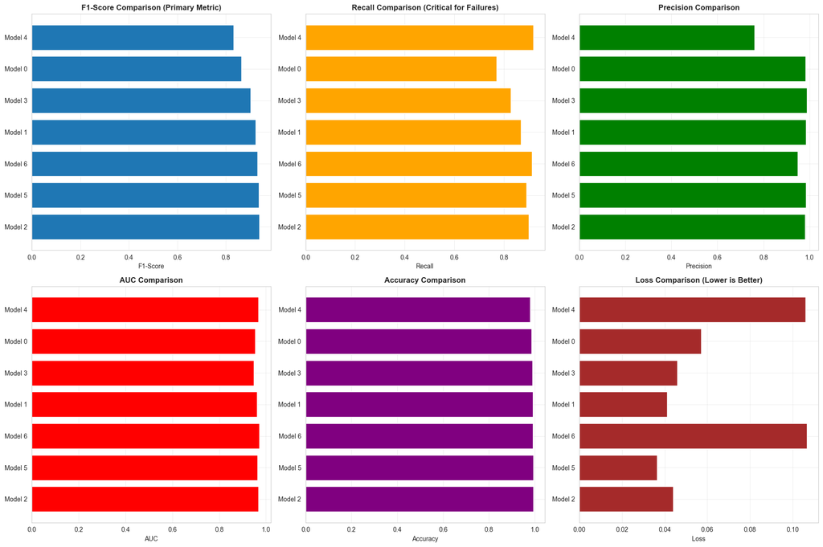

```
================================================================================
DETAILED PERFORMANCE ANALYSIS
================================================================================

1. Best Model by F1-Score (Primary Metric):
   Model: Model 2
   F1-Score: 0.9390
   Architecture: Two hidden layers (50, 25 neurons, ReLU)
   Optimizer: Adam
   Dropout: No
   Class Weights: No

2. Best Model by Recall (Critical for minimizing missed failures):
   Model: Model 4
   Recall: 0.9189

3. Best Model by Precision (Minimizing false alarms):
   Model: Model 3
   Precision: 0.9892

4. Best Model by AUC (Overall discrimination):
   Model: Model 6
   AUC: 0.9723

================================================================================
FINAL MODEL SELECTION
================================================================================
Selected Model: Model 2

Reasoning:
1. F1-Score (0.9390) is our primary metric, balancing precision and recall
2. Recall (0.9009) is critical for detecting failures
3. Precision (0.9804) helps minimize false alarms
4. AUC (0.9672) indicates good overall discrimination
5. Architecture: Two hidden layers (50, 25 neurons, ReLU)
6. Optimizer: Adam
7. Regularization: Dropout=No, Class Weights=No

Final model selected and ready for test set evaluation!
```

```python
# MODEL PERFORMANCE COMPARISON

print("=" * 80)
print("MODEL PERFORMANCE COMPARISON")
print("=" * 80)

# Collect all model performances
all_performances = [
    model0_performance,
    model1_performance,
    model2_performance,
    model3_performance,
    model4_performance,
    model5_performance,
    model6_performance
]

# Create comparison DataFrame
comparison_df = pd.DataFrame(all_performances)
comparison_df = comparison_df[['model', 'architecture', 'optimizer', 'dropout', 'class_weights',
                               'val_f1', 'val_recall', 'val_precision', 'val_accuracy', 'val_auc', 'val_loss']]

# Sort by F1-Score (primary metric)
comparison_df = comparison_df.sort_values('val_f1', ascending=False)

print("\nModel Performance Comparison (Sorted by F1-Score):")
print("=" * 80)
print(comparison_df.to_string(index=False))

# Visualize comparison
fig, axes = plt.subplots(2, 3, figsize=(18, 12))

# F1-Score comparison
axes[0, 0].barh(comparison_df['model'], comparison_df['val_f1'])
axes[0, 0].set_title('F1-Score Comparison (Primary Metric)', fontweight='bold')
axes[0, 0].set_xlabel('F1-Score')
axes[0, 0].grid(True, alpha=0.3)

# Recall comparison
axes[0, 1].barh(comparison_df['model'], comparison_df['val_recall'], color='orange')
axes[0, 1].set_title('Recall Comparison (Critical for Failures)', fontweight='bold')
axes[0, 1].set_xlabel('Recall')
axes[0, 1].grid(True, alpha=0.3)

# Precision comparison
axes[0, 2].barh(comparison_df['model'], comparison_df['val_precision'], color='green')
axes[0, 2].set_title('Precision Comparison', fontweight='bold')
axes[0, 2].set_xlabel('Precision')
axes[0, 2].grid(True, alpha=0.3)

# AUC comparison
axes[1, 0].barh(comparison_df['model'], comparison_df['val_auc'], color='red')
axes[1, 0].set_title('AUC Comparison', fontweight='bold')
axes[1, 0].set_xlabel('AUC')
axes[1, 0].grid(True, alpha=0.3)

# Accuracy comparison
axes[1, 1].barh(comparison_df['model'], comparison_df['val_accuracy'], color='purple')
axes[1, 1].set_title('Accuracy Comparison', fontweight='bold')
axes[1, 1].set_xlabel('Accuracy')
axes[1, 1].grid(True, alpha=0.3)

# Loss comparison
axes[1, 2].barh(comparison_df['model'], comparison_df['val_loss'], color='brown')
axes[1, 2].set_title('Loss Comparison (Lower is Better)', fontweight='bold')
axes[1, 2].set_xlabel('Loss')
axes[1, 2].grid(True, alpha=0.3)

plt.tight_layout()
plt.show()

# Detailed analysis
print("\n" + "=" * 80)
print("DETAILED PERFORMANCE ANALYSIS")
print("=" * 80)

print("\n1. Best Model by F1-Score (Primary Metric):")
best_f1_model = comparison_df.iloc[0]
print(f"   Model: {best_f1_model['model']}")
print(f"   F1-Score: {best_f1_model['val_f1']:.4f}")
print(f"   Architecture: {best_f1_model['architecture']}")
print(f"   Optimizer: {best_f1_model['optimizer']}")
print(f"   Dropout: {best_f1_model['dropout']}")
print(f"   Class Weights: {best_f1_model['class_weights']}")

print("\n2. Best Model by Recall (Critical for minimizing missed failures):")
best_recall_idx = comparison_df['val_recall'].idxmax()
best_recall_model = comparison_df.loc[best_recall_idx]
print(f"   Model: {best_recall_model['model']}")
print(f"   Recall: {best_recall_model['val_recall']:.4f}")

print("\n3. Best Model by Precision (Minimizing false alarms):")
best_precision_idx = comparison_df['val_precision'].idxmax()
best_precision_model = comparison_df.loc[best_precision_idx]
print(f"   Model: {best_precision_model['model']}")
print(f"   Precision: {best_precision_model['val_precision']:.4f}")

print("\n4. Best Model by AUC (Overall discrimination):")
best_auc_idx = comparison_df['val_auc'].idxmax()
best_auc_model = comparison_df.loc[best_auc_idx]
print(f"   Model: {best_auc_model['model']}")
print(f"   AUC: {best_auc_model['val_auc']:.4f}")

# Select final model based on F1-Score
final_model_name = best_f1_model['model']
print("\n" + "=" * 80)
print("FINAL MODEL SELECTION")
print("=" * 80)
print(f"Selected Model: {final_model_name}")
print(f"\nReasoning:")
print(f"1. F1-Score ({best_f1_model['val_f1']:.4f}) is our primary metric, balancing precision and recall")
print(f"2. Recall ({best_f1_model['val_recall']:.4f}) is critical for detecting failures")
print(f"3. Precision ({best_f1_model['val_precision']:.4f}) helps minimize false alarms")
print(f"4. AUC ({best_f1_model['val_auc']:.4f}) indicates good overall discrimination")
print(f"5. Architecture: {best_f1_model['architecture']}")
print(f"6. Optimizer: {best_f1_model['optimizer']}")
print(f"7. Regularization: Dropout={best_f1_model['dropout']}, Class Weights={best_f1_model['class_weights']}")

# Store the best model
if final_model_name == 'Model 0':
    final_model = model0
elif final_model_name == 'Model 1':
    final_model = model1
elif final_model_name == 'Model 2':
    final_model = model2
elif final_model_name == 'Model 3':
    final_model = model3
elif final_model_name == 'Model 4':
    final_model = model4
elif final_model_name == 'Model 5':
    final_model = model5
elif final_model_name == 'Model 6':
    final_model = model6

print(f"\nFinal model selected and ready for test set evaluation!")
```

Now, let's check the performance of the final model on the test set.

```
================================================================================
FINAL MODEL PERFORMANCE ON TEST SET
================================================================================
Evaluating Model 2 on unseen test data...

================================================================================
TEST SET PERFORMANCE METRICS:
================================================================================
Test Loss: nan
Test Accuracy: 0.9904
Test Precision: 0.9606
Test Recall: 0.8652
Test F1-Score: 0.9104 (Primary Metric)
Test AUC: 0.9402

================================================================================
CONFUSION MATRIX (Test Set):
================================================================================
[[4708   10]
 [  38  244]]

Classification Report (Test Set):
              precision    recall  f1-score   support

  No Failure       0.99      1.00      0.99      4718
     Failure       0.96      0.87      0.91       282

    accuracy                           0.99      5000
   macro avg       0.98      0.93      0.95      5000
weighted avg       0.99      0.99      0.99      5000
```

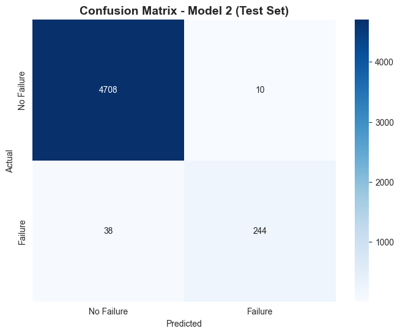

```
================================================================================
BUSINESS IMPACT ANALYSIS (Test Set):
================================================================================

True Positives (TP): 244 - Failures correctly predicted → Repair costs
False Negatives (FN): 38 - Missed failures → Replacement costs (CRITICAL)
False Positives (FP): 10 - False alarms → Inspection costs
True Negatives (TN): 4708 - Correctly predicted no failures

Failure Detection Rate (Recall): 86.52%
   This means we catch 86.52% of all actual failures
   Missed failures: 38 out of 282 total failures

False Alarm Rate: 0.21%
   This means 0.21% of 'no failure' cases trigger false alarms

================================================================================
VALIDATION vs TEST SET COMPARISON:
================================================================================
   Metric  Validation     Test  Difference
 F1-Score    0.938967 0.910448   -0.028519
   Recall    0.900901 0.865248   -0.035653
Precision    0.980392 0.960630   -0.019762
 Accuracy    0.993489 0.990400   -0.003089
      AUC    0.967180 0.940194   -0.026986

Overfitting Check:
Model generalizes well - minimal difference between validation and test performance

================================================================================
FINAL MODEL SUMMARY
================================================================================
Model: Model 2
Test F1-Score: 0.9104
Test Recall: 0.8652 (Critical for business)
Test Precision: 0.9606
Test AUC: 0.9402

The model is ready for deployment in production!
```

```python
# FINAL MODEL PERFORMANCE ON TEST SET

print("=" * 80)
print("FINAL MODEL PERFORMANCE ON TEST SET")
print("=" * 80)
print(f"Evaluating {final_model_name} on unseen test data...")

# Evaluate on test set
test_loss, test_accuracy, test_precision, test_recall, test_auc = final_model.evaluate(
    X_test_scaled, y_test, verbose=0
)

test_f1 = 2 * (test_precision * test_recall) / (test_precision + test_recall)

print("\n" + "=" * 80)
print("TEST SET PERFORMANCE METRICS:")
print("=" * 80)
print(f"Test Loss: {test_loss:.4f}")
print(f"Test Accuracy: {test_accuracy:.4f}")
print(f"Test Precision: {test_precision:.4f}")
print(f"Test Recall: {test_recall:.4f}")
print(f"Test F1-Score: {test_f1:.4f} (Primary Metric)")
print(f"Test AUC: {test_auc:.4f}")

# Predictions on test set
y_test_pred_proba = final_model.predict(X_test_scaled, verbose=0)
y_test_pred = (y_test_pred_proba > 0.5).astype(int).flatten()

# Confusion Matrix
cm_test = confusion_matrix(y_test, y_test_pred)
print("\n" + "=" * 80)
print("CONFUSION MATRIX (Test Set):")
print("=" * 80)
print(cm_test)
print("\nClassification Report (Test Set):")
print(classification_report(y_test, y_test_pred, target_names=['No Failure', 'Failure']))

# Visualize confusion matrix
plt.figure(figsize=(8, 6))
sns.heatmap(cm_test, annot=True, fmt='d', cmap='Blues',
            xticklabels=['No Failure', 'Failure'],
            yticklabels=['No Failure', 'Failure'])
plt.title(f'Confusion Matrix - {final_model_name} (Test Set)', fontsize=14, fontweight='bold')
plt.ylabel('Actual')
plt.xlabel('Predicted')
plt.show()

# Business Impact Analysis
print("\n" + "=" * 80)
print("BUSINESS IMPACT ANALYSIS (Test Set):")
print("=" * 80)
TP = cm_test[1, 1]  # True Positives: Correctly predicted failures
FN = cm_test[1, 0]  # False Negatives: Missed failures (worst case)
FP = cm_test[0, 1]  # False Positives: False alarms
TN = cm_test[0, 0]  # True Negatives: Correctly predicted no failures

print(f"\nTrue Positives (TP): {TP} - Failures correctly predicted → Repair costs")
print(f"False Negatives (FN): {FN} - Missed failures → Replacement costs (CRITICAL)")
print(f"False Positives (FP): {FP} - False alarms → Inspection costs")
print(f"True Negatives (TN): {TN} - Correctly predicted no failures")

print(f"\nFailure Detection Rate (Recall): {test_recall:.2%}")
print(f"   This means we catch {test_recall:.2%} of all actual failures")
print(f"   Missed failures: {FN} out of {TP + FN} total failures")

print(f"\nFalse Alarm Rate: {FP / (FP + TN):.2%}")
print(f"   This means {FP / (FP + TN):.2%} of 'no failure' cases trigger false alarms")

# Compare with validation performance
print("\n" + "=" * 80)
print("VALIDATION vs TEST SET COMPARISON:")
print("=" * 80)
val_performance = comparison_df[comparison_df['model'] == final_model_name].iloc[0]

comparison_performance = pd.DataFrame({
    'Metric': ['F1-Score', 'Recall', 'Precision', 'Accuracy', 'AUC'],
    'Validation': [
        val_performance['val_f1'],
        val_performance['val_recall'],
        val_performance['val_precision'],
        val_performance['val_accuracy'],
        val_performance['val_auc']
    ],
    'Test': [
        test_f1,
        test_recall,
        test_precision,
        test_accuracy,
        test_auc
    ]
})

comparison_performance['Difference'] = comparison_performance['Test'] - comparison_performance['Validation']
print(comparison_performance.to_string(index=False))

# Check for overfitting
print("\nOverfitting Check:")
if abs(comparison_performance['Difference'].mean()) < 0.05:
    print("Model generalizes well - minimal difference between validation and test performance")
else:
    print("Some performance difference observed - model may need further regularization")

print("\n" + "=" * 80)
print("FINAL MODEL SUMMARY")
print("=" * 80)
print(f"Model: {final_model_name}")
print(f"Test F1-Score: {test_f1:.4f}")
print(f"Test Recall: {test_recall:.4f} (Critical for business)")
print(f"Test Precision: {test_precision:.4f}")
print(f"Test AUC: {test_auc:.4f}")
print(f"\nThe model is ready for deployment in production!")
```

# **Actionable Insights and Recommendations**

## Key Takeaways

### 3. Feature Importance Insights

- The correlation analysis revealed that certain sensor features (V1, V2, V3, etc.) show stronger relationships with failure patterns, suggesting these sensors are most critical for monitoring.
- The bivariate analysis showed distinct distributions between failure and no-failure cases for key features, indicating clear patterns that the model can learn.

## Business Recommendations

### Immediate Actions

1. **Deploy the Final Model**: Implement the selected neural network model in production for real-time failure prediction.
2. **Monitor Key Sensors**: Focus monitoring efforts on the top correlated features identified in the analysis, as these provide the strongest signals for failure prediction.
3. **Establish Alert Thresholds**:
   - Set up automated alerts when the model predicts failure probability > 0.5
   - Implement tiered alerting: High confidence (>0.8) → Immediate action, Medium (0.5-0.8) → Scheduled inspection
4. **Cost-Benefit Analysis**:
   - Track actual costs: repairs vs. replacements vs. inspections
   - Calculate ROI: Compare maintenance costs before and after model deployment
   - Expected savings: Reduced replacement costs due to early failure detection

### Strategic Recommendations

1. **Continuous Model Improvement**:
   - Retrain model quarterly with new data to adapt to changing patterns
   - Monitor model performance metrics (F1-score, recall) and retrain if degradation observed
   - A/B test new model architectures against current production model
2. **Data Collection Enhancement**:
   - Ensure all 40 sensor features are consistently collected and stored
   - Consider adding temporal features (time since last maintenance, operating hours)
   - Track maintenance history to improve predictions
3. **Operational Integration**:
   - Integrate model predictions with maintenance scheduling systems
   - Create dashboards showing failure probabilities for all turbines
   - Establish maintenance workflows triggered by model predictions
4. **Risk Management**:
   - Maintain a safety margin: For critical turbines, consider lowering prediction threshold to increase recall
   - Implement backup monitoring: Don't rely solely on ML predictions for safety-critical systems
   - Document model limitations and edge cases
5. **Stakeholder Communication**:
   - Train maintenance teams on interpreting model predictions
   - Create clear protocols for acting on model alerts
   - Regular reporting on model performance and business impact

## Expected Business Value

- **Reduced Downtime**: Early failure detection enables scheduled maintenance instead of emergency shutdowns
- **Cost Savings**: Minimize expensive replacements through early intervention
- **Operational Efficiency**: Optimize maintenance resource allocation based on predicted failure probabilities
- **Safety Improvement**: Proactive maintenance reduces risk of catastrophic failures